# Forecasting Singapore’s Consumer Price Index Using Different Time Series Models

Tan Zheng Liang

2022-07-01

Updated on: 2022-07-29

## 1 Introduction

The purpose of this project is to introduce time series modelling and forecasting in R using a practical example. It covers the common tests that are done in time series analysis, such as unit root tests for stationarity, Breusch-Godfrey test for serial correlation, and Granger Causality test for determining whether variables are useful in forecasting other variables. The main models used in this project are the ARIMA, ARDL and VAR models, which will be discussed in detail in the later sections. However, I would not be tackling the issue of seasonality in this project as it will become a lengthy discussion. Instead, I would do this in a future project as I get more familiar with the treatment of seasonal effects on time series.

I attempted to forecast Singapore’s Consumer Price Index (CPI) using the Producer Price Index (PPI) and the Composite Leading Index (CLI). The data used in this project was obtained from the Department of Statistics (DOS) Singapore and can be accessed from the [SingStat Table Builder](https://tablebuilder.singstat.gov.sg/). The data was imported via an API, but it can also be downloaded as an Excel or CSV file.

## 2 Packages Required

```r
# Use install.packages("packagename") if they are not already installed

# Packages that will be needed for obtaining data via an API
library(httr)
library(jsonlite)

# Packages that produces neat regression tables (only when possible)
library(broom)
library(knitr)
library(stargazer)

# Packages that will be needed for the main parts of the project
library(ARDL) # For ARDL models lag selection
library(bruceR) # For multivariate granger causality test
```

```r
library(corrplot) # For visualizing correlation between variables
library(dLagM) # For creating ARDL objects that can work with a forecast function
library(forecast) # For ARIMA models, forecasting and evaluation
library(lmtest) # For tests such as Breusch-Godfrey, Breusch-Pagan
library(lubridate) # For working with dates
library(tidyverse) # For ggplot2 and dplyr
library(urca) # For unit root tests
library(xts) # For converting data to and working with xts objects
library(vars) # For VAR models
```

## 3 Importing Data Using API

To import data using an API, we need to use the **`GET`** function in the `httr` package. We need to specify a URL to send a request for data retrieval. Websites that has an API usually has their own documentation on how to structure the parameters of the URL. For DOS Singapore, the documentation can be found [here](https://tablebuilder.singstat.gov.sg/view-api/for-developers).

I have included the process in detail for retrieving the “[Consumer Price Index, 2019 As Base Year](https://tablebuilder.singstat.gov.sg/table/TS/M212881)” data. For the rest of the variables, I would run the steps in a single R chunk for each variable.

```r
cpi_url <- "https://tablebuilder.singstat.gov.sg/api/table/tabledata/M212881?isTestApi=true&seriesNoORrowNo=1"

raw_cpi <- httr::GET(url = cpi_url)
```

It has returned a list object which we can further explore by calling `raw_cpi`.

```r
raw_cpi
```

```
## Response [https://tablebuilder.singstat.gov.sg/api/table/tabledata/M212881?isTestApi=true&seriesNoORrowNo=1]
##   Date: 2022-07-29 15:26
##   Status: 200
##   Content-Type: application/json; charset=utf-8
##   Size: 45.4 kB
```

```r
names(raw_cpi)
```

```
##  [1] "url"         "status_code" "headers"     "all_headers" "cookies"
##  [6] "content"     "date"        "times"       "request"     "handle"
```

```r
head(raw_cpi$content)
```

```
## [1] 7b 22 44 61 74 61
```

The `Status: 200` tells us that the operation was successful. If it returned the number 400 or 404, it would mean that there are errors in our query or the resource could not be found. The `Content-Type` tells us that the data takes on a JSON format, which is why the `jsonlite` package was needed.

Using the **`names`** function, we can find out what is in the `raw_cpi` list. The most important part we need is in the `content`, which is not useful until we convert it to text in a JSON format. To do this, we need the **`rawToChar`** in base R and **`fromJSON`** function in the `jsonlite` package.

```r
cpi <- jsonlite::fromJSON(rawToChar(raw_cpi$content))

names(cpi)
```

```
## [1] "Data"       "DataCount"  "StatusCode" "Message"
```

```r
lapply(cpi, FUN = class)
```

```
## $Data
## [1] "list"
##
## $DataCount
## [1] "integer"
##
## $StatusCode
## [1] "integer"
##
## $Message
## [1] "character"
```

Using the **`names`** function on the resulting `cpi` list, we can find the elements in the list and we are interested in the `Data` element. Using the **`lapply`** function and indicating **`FUN = class`**, it returned the classes of the elements in the list. Let us dig deeper into the `Data` element.

```r
names(cpi$Data)
```

```
##  [1] "id"              "title"           "footnote"        "frequency"
##  [5] "datasource"      "generatedBy"     "dataLastUpdated" "dateGenerated"
##  [9] "offset"          "limit"           "sortBy"          "timeFilter"
## [13] "between"         "search"          "row"
```

```r
names(cpi$Data$row)
```

```
## [1] "seriesNo" "rowText"  "uoM"      "footnote" "columns"
```

```r
head(lapply(cpi$Data$row$columns, dim))
```

```
## [[1]]
## [1] 738   2
##
## [[2]]
## [1] 0 0
##
## [[3]]
## [1] 0 0
##
## [[4]]
## [1] 0 0
##
## [[5]]
## [1] 0 0
##
## [[6]]
## [1] 0 0
```

The `Data` list consists of the type of data and some of the values in each element. The elements `id`, `title`, `frequency`, etc. are the parameters or metadata from the API query. What we need is the `row` element. The `seriesNo` and `rowText`represents the class and sub-classes of items in the CPI basket, for example 1 refers to All Items, 1.0 refers to Food, and 1.1 refers to Food Excl Food Serving Services, etc. For our analysis, I am interested in the CPI - All Items, and due to a parameter in our URL specifying to only return the values under this category, we only have data for it as can be seen in the `columns` element. Due to the size of the `columns` list, I had to use the **`head`** function to simplify the output.

Working with list of lists can be troublesome, so it would a good idea to convert it into a data frame (at least for now).

```r
cpi_data <- as.data.frame(cpi$Data$row$columns[[1]])
```

Let us take a look at `cpi_data`.

```r
stargazer(rbind(head(cpi_data, n = 8), tail(cpi_data, n = 8)),
          type = "text",
          title = "First and Last 8 Values in cpi data",
          summary = F)
```

```
##
## First and Last 8 Values in cpi data
## ====================
##       key     value
## --------------------
## 1   1961 Apr 24.187
## 2   1961 Aug 24.517
## 3   1961 Dec 24.487
## 4   1961 Feb 24.565
## 5   1961 Jan 24.542
## 6   1961 Jul 24.276
## 7   1961 Jun 24.223
## 8   1961 Mar 24.585
## 731 2021 Oct 102.95
## 732 2021 Sep 102.657
## 733 2022 Apr 106.547
## 734 2022 Feb 105.379
## 735 2022 Jan 104.472
## 736 2022 Jun 108.671
## 737 2022 Mar 106.691
## 738 2022 May 107.598
## --------------------
```

We can see that the order of the data is based on the time observations but on the character values of the dates. To reorder the observations, we can use the functions in the **`lubridate`** and **`dplyr`** packages.

```r
cpi_data <- cpi_data %>%
  dplyr::arrange(lubridate::ym(cpi_data$key))

stargazer(rbind(head(cpi_data, n = 8), tail(cpi_data, n = 8)),
          type = "text",
          title = "Adjusted First and Last 8 Values in cpi data",
          summary = F)
```

```
##
## Adjusted First and Last 8 Values in cpi data
## ====================
##       key     value
## --------------------
## 1   1961 Jan 24.542
## 2   1961 Feb 24.565
## 3   1961 Mar 24.585
## 4   1961 Apr 24.187
## 5   1961 May 24.053
## 6   1961 Jun 24.223
## 7   1961 Jul 24.276
## 8   1961 Aug 24.517
## 731 2021 Nov 103.959
## 732 2021 Dec 104.439
## 733 2022 Jan 104.472
## 734 2022 Feb 105.379
## 735 2022 Mar 106.691
## 736 2022 Apr 106.547
## 737 2022 May 107.598
## 738 2022 Jun 108.671
## --------------------
```

I have simplified the steps for data retrieval and conversion into data frame for the other variables of interest.

[Domestic Supply Price Index, By Commodity Section (1-Digit Level), Base Year 2018 = 100](https://tablebuilder.singstat.gov.sg/table/TS/M212701):

```r
dspi_url <- "https://tablebuilder.singstat.gov.sg/api/table/tabledata/M212701?isTestApi=true&seriesNoORrowNo=1"

raw_dspi <- httr::GET(url = dspi_url)

dspi <- jsonlite::fromJSON(rawToChar(raw_dspi$content))

dspi_data <- as.data.frame(dspi$Data$row$columns[[1]])

dspi_data <- dspi_data %>%
  dplyr::arrange(lubridate::ym(dspi_data$key))

stargazer(rbind(head(dspi_data, n = 8), tail(dspi_data, n = 8)),
          type = "text",
          title = "Adjusted First and Last 8 Values in dspi data",
          summary = F)
```

```
##
## Adjusted First and Last 8 Values in dspi data
## ====================
##       key     value
## --------------------
## 1   1974 Jan 79.774
## 2   1974 Feb 80.715
## 3   1974 Mar 81.278
## 4   1974 Apr  81.56
## 5   1974 May 81.842
## 6   1974 Jun 81.278
## 7   1974 Jul  81.09
## 8   1974 Aug  81.56
## 575 2021 Nov 109.496
## 576 2021 Dec 108.262
## 577 2022 Jan 111.692
## 578 2022 Feb 115.835
## 579 2022 Mar 125.088
## 580 2022 Apr 127.24
## 581 2022 May 129.836
## 582 2022 Jun 129.371
## --------------------
```

[Composite Leading Index (2015 = 100)](https://tablebuilder.singstat.gov.sg/table/TS/M240421):

```r
cli_url <- "https://tablebuilder.singstat.gov.sg/api/table/tabledata/M240421?isTestApi=true"

raw_cli <- httr::GET(url = cli_url)

cli <- jsonlite::fromJSON(rawToChar(raw_cli$content))

cli_data <- as.data.frame(cli$Data$row$columns[[1]])

# Data is ordered by the years and quarters so there was no need for reordering

stargazer(rbind(head(cli_data, n = 8), tail(cli_data, n = 8)),
          type = "text",
          title = "First and Last 8 Values in cli data",
          summary = F)
```

```
##
## First and Last 8 Values in cli data
## =================
##       key   value
## -----------------
## 1   1978 1Q 25.7
## 2   1978 2Q 26.5
## 3   1978 3Q 27.2
## 4   1978 4Q 26.6
## 5   1979 1Q 27.8
## 6   1979 2Q 27.4
## 7   1979 3Q 27.4
## 8   1979 4Q 28.3
## 170 2020 2Q 100.6
## 171 2020 3Q 107.4
## 172 2020 4Q  111
## 173 2021 1Q 110.9
## 174 2021 2Q 112.1
## 175 2021 3Q  112
## 176 2021 4Q 112.9
## 177 2022 1Q 112.3
## -----------------
```

## 4 Exploratory Data Analysis

In this section, I provided more details about each variable and generated univariate and multivariate plots to find patterns in and interaction between the variables.

### 4.1 Changing Data Format

To visualize the plots, rather than using a data frame object, it is best to convert them into an `xts` object. The conversion requires two arguments. First is the vector or matrix to be converted to xts object and a vector of the date. We have the dates in the data frame but they are not formatted as dates, so I used the **`yearmon`** and **`yearqtr`** functions to format them to the appropriate types.

```r
cpi.xts <- xts(x = cpi_data$value,
               order.by = as.yearmon(cpi_data$key, format = "%Y %b")) %>%
  `colnames<-`("CPI")

dspi.xts <- xts(x = dspi_data$value,
                order.by = as.yearmon(dspi_data$key, format = "%Y %b")) %>%
  `colnames<-`("DSPI")

cli.xts <- xts(x = cli_data$value,
               order.by = as.yearqtr(gsub("Q", "", cli_data$key), format = "%Y %q")) %>%
  `colnames<-`("CLI")
```

Since the values were stored as characters, I converted them to numeric so that it can be properly analyzed. Unlike the normal data frame, we cannot use **`as.numeric`** function to convert the variable type to numeric. Instead, we need to use **`storage.mode`**.

```r
storage.mode(cpi.xts) <- "numeric"

storage.mode(dspi.xts) <- "numeric"

storage.mode(cli.xts) <- "numeric"
```

### 4.2 Consumer Price Index

One of the widely-known and most watched indicator is the CPI as it can be used to determine the general inflation in a country. Inflation basically refers to the increase in general price levels of goods and services. Deflation (or negative inflation) would mean that the general price level of goods and services has fallen. The CPI measures the average price level of a basket of goods and services consumed by households, and the basket of goods is updated every five years in Singapore to better reflect the changing consumption habits. Due to the importance of the indicator, many economists in government or private business settings attempt to forecast it to formulate economic policies or business/investment decisions.

`cpi.xts` contained 738 monthly observations from January 1961 to June 2022. However, I would need to adjust this variable as the Composite Leading Index starts from 1978 and it is a quarterly series. For time series analysis to work, we need the variables to have same time interval.

```r
cpi_q.xts <- xts::apply.quarterly(cpi.xts, FUN = mean)

# Changing the date index to an appropriate format
tclass(cpi_q.xts) <- "yearqtr"
```

```r
#Subset cpi_q to match the cli data

cpi_q.xts <- cpi_q.xts["1978-01/2022-03"]
```

I have plotted the cleaned `cpi_q.xts`, which shows how the CPI has changed over time. We can see that the series is non-stationary, which could probably be solved by taking the first difference on the data. More about this in the next section.

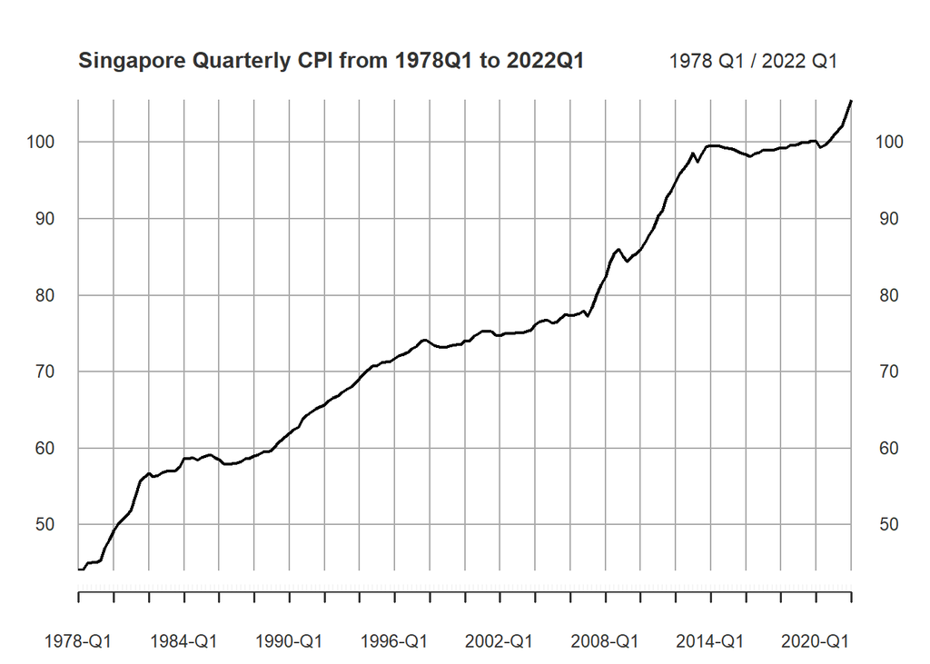

### 4.3 Domestic Supply Price Index

There are 3 different measurements of the PPI in Singapore, namely the Domestic Supply Price Index, the Singapore Manufactured Products Price Index and the Services Producer Price Index. Here are the descriptions of each index:

| Index | Description |
| --- | --- |
| DSPI | Monitors the price changes of locally manufactured goods and imports which are retained for use in the domestic economy. It gives an indication of the price trends of goods used in the domestic econom… |
| SMPPI | Measures the changes in the prices of goods produced by manufacturers in Singapore for sale in the domestic and international markets. |
| SPPI | Contains indices of different services: Accounting Services Price Index, Cargo Handling Price Index, Computer Consultancy and Information Services Price Index, Freight Forwarding Price Index, Sea Frei… |

The index I am interested in is the DSPI since it measures the prices of goods used in the domestic economy, including goods that were imported. It may give a better measure of the PPI, since these are the costs affecting the domestic manufacturers and would flow down the supply chain and affect the domestic end-consumers. We would expect that if PPI increases, CPI would increase as well.

Similar to `cpi.xts`, `dspi.xts` 582 monthly observations from January 1974 to June 2022. We would need to adjust the time interval to match the CLI data.

```r
dspi_q.xts <- xts::apply.quarterly(dspi.xts, FUN = mean)

tclass(dspi_q.xts) <- "yearqtr"

dspi_q.xts <- dspi_q.xts["1978-01/2022-03"]
```

Based on the plot of `dspi_q.xts`, the Singapore DSPI has ranged from a minimum of about 80 to a maximum of about 130. This is unlike the CPI chart that we saw earlier that had a clear upward trend.

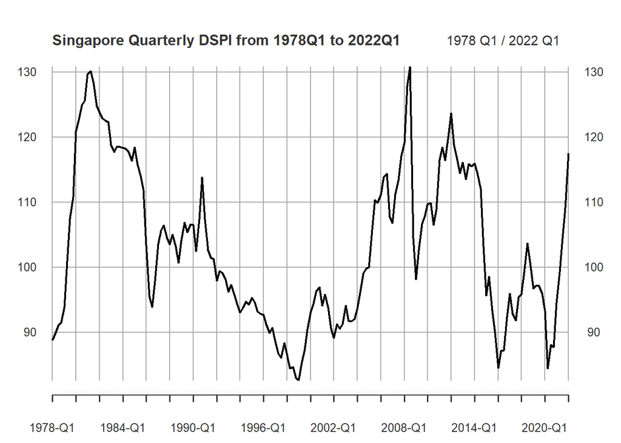

### 4.4 Composite Leading Index

The CLI is a leading indicator to predict market expansions and slowdowns. It aggregates the following nine indicators:

- Total New Companies Formed
- Money Supply (M2)
- Stock Exchange of Singapore Indices
- Business Expectations for Wholesale Trade
- Business Expectations for Stock of Finished Goods (Manufacturing)
- US Purchasing Managers’ Index (Manufacturing)
- Total Non-oil Seaborne Cargo Handled
- Domestic Liquidity Indicator
- Total Non-oil Retained Imports

We could expect that if the CLI indicates a market upturn(downturn), CPI would increase(decrease).

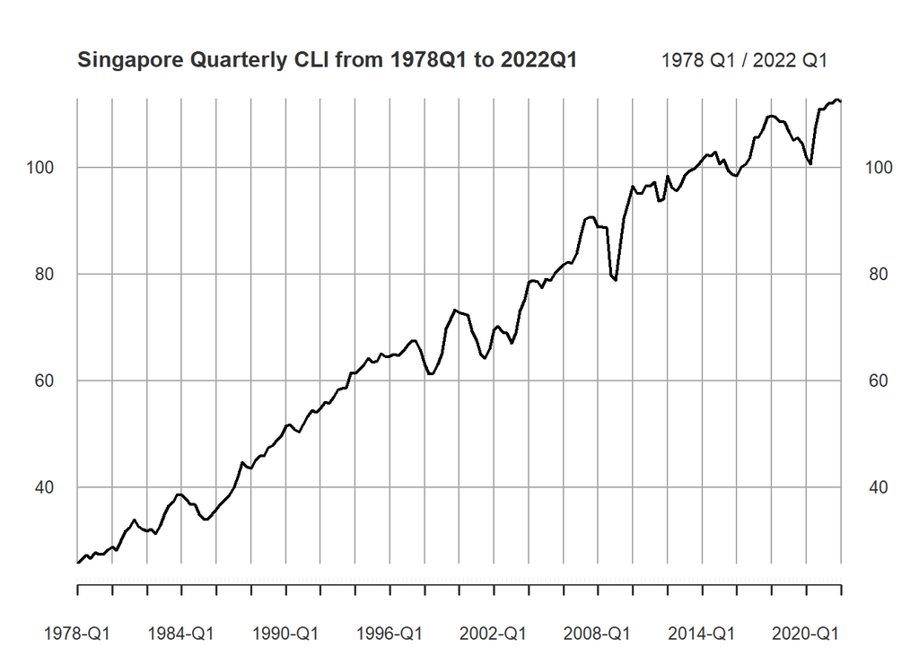

### 4.5 Multivariate Analysis

Before conducting a multivariate analysis, it would be better to merge our data into a single object. To do this, we need the **`merge`** function. However, we can see there seems to be a problem, as there are two rows for each quarter in the year. This is because CPI and DSPI considered the quarter to be on March, June, September and December due to the adjustment we did previously.

```r
data <- merge(cpi_q.xts, dspi_q.xts, cli.xts)

stargazer(head(data, n = 8),
          type = "text",
          title = "Unadjusted data",
          rownames = T)
```

```
##
## Unadjusted data
## ===============================
##             CPI    DSPI   CLI
## -------------------------------
## X1978.Q1                 25.700
## X1978.Q1.1 44.057 88.732
## X1978.Q2                 26.500
## X1978.Q2.1 44.160 89.923
## X1978.Q3                 27.200
## X1978.Q3.1 44.975 91.018
## X1978.Q4                 26.600
## X1978.Q4.1 45.098 91.458
## -------------------------------
```

To resolve this, we can use the **`na.locf`** function to replace the NAs with the last observation. We can do this on the column, and use the **`na.omit`** function to remove rows with NAs in the CPI and DSPI columns. This would remove the duplication of the quarters in each year.

```r
data[, 3] <- na.locf(data[, 3])

data <- na.omit(data)

stargazer(head(data, n = 8),
          type = "text",
          title = "Adjusted data",
          rownames = T)
```

```
##
## Adjusted data
## =============================
##          CPI    DSPI    CLI
## -----------------------------
## 1978 Q1 44.057 88.732  25.700
## 1978 Q2 44.160 89.923  26.500
## 1978 Q3 44.975 91.018  27.200
## 1978 Q4 45.098 91.458  26.600
## 1979 Q1 45.052 93.869  27.800
## 1979 Q2 45.371 100.885 27.400
## 1979 Q3 46.919 107.525 27.400
## 1979 Q4 48.089 110.782 28.300
## -----------------------------
```

```r
dim(data)
```

```
## [1] 177   3
```

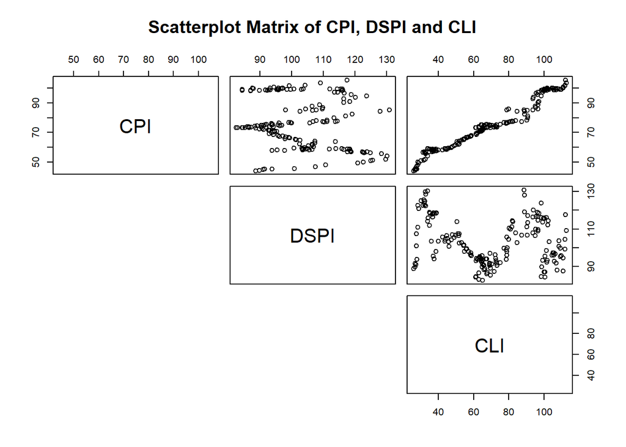

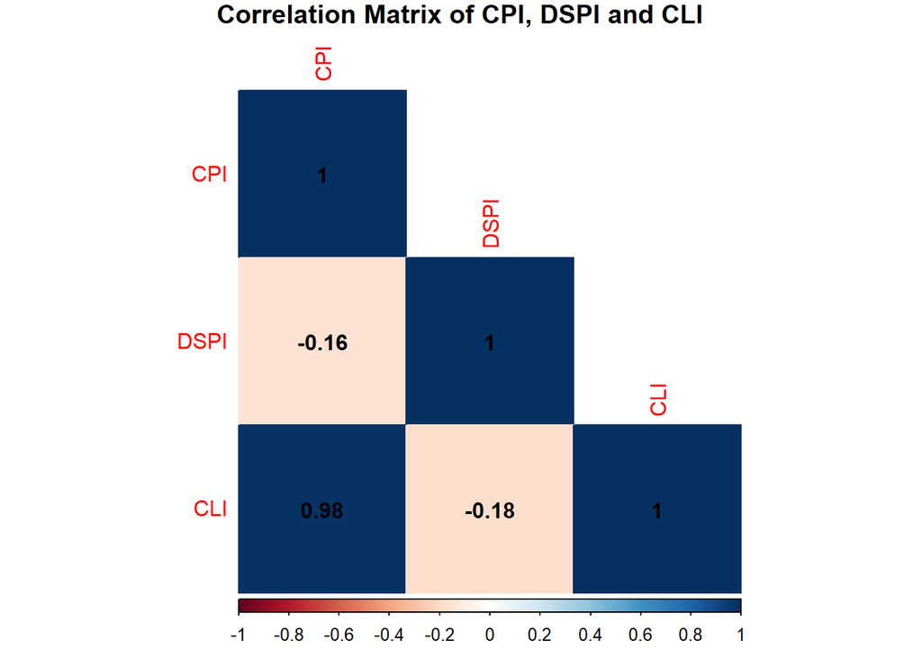

## 5 Training and Testing Data Sets

Before we continue with the analysis, it would be better to split our data into training and testing sets. The training set will be used to create our models, while the testing set will be used to evaluate our models on out-of-sample prediction. Unlike cross-sectional data, the splitting of the data can only happen at a certain observation and not randomly selected to preserve the stochastic process of the observations.

```r
train <- data["/2019"]

test <- data["2020/"]
```

## 6 Unit Root Test for Stationarity

Now that we have a better understanding of our variables, we can proceed with the actual time series analysis. However, the first thing to do before modelling is to check that the variables are stationary.

Stationarity of variables is an important condition in most time series models as regression with non-stationary variables can lead to spurious results. Time series are said to be stationary if they have a constant mean, constant variance and the covariance between observations $h$ periods apart depends on $h$. This type of stationarity is called covariance (weak) stationarity.

A common test for stationarity is the Augmented Dickey-Fuller (ADF) unit root test. The null hypothesis claims that there is unit root in the series and hence it is non-stationary, while the alternative hypothesis claims that there is no unit root in the series. An alternative is the Phillips-Perron (PP) unit root test, which has the same null and alternative hypothesis as the ADF test. Kwiatkowski-Phillips-Schmidt-Shin (KPSS) test is a test to check for the stationarity of time series variables. KPSS test is commonly used in conjunction with the ADF or PP test. The the hypotheses of KPSS test is opposite to that of ADF and PP test, with the null claiming that the time series is stationary with deterministic trend and the alternative claiming that it is not stationary.

If a series is non-stationary, it is common to take the first difference (i.e. $y_t$ - $y_{t-1}$) or to de-trend a trend stationary series. If a series is stationary after taking the first difference, we now have an I(1) series or we can say that the variable is integrated of order 1. The original series (or at levels) is I(0), if stationary.

I performed the ADF and KPSS test on the three variables in the `data` object, firstly on the variables at levels then at first differences, using the **`ur.df`** and **`ur.kpss`** function in the **`urca`** package.

### 6.1 CPI at level

```r
# Indicate type = "trend" as there was trend in the series based on plot
# Indicate selectlags = "AIC" to select lags based on Akaike IC

train$CPI %>%
  ur.df(type = "trend", selectlags = "AIC") %>%
  summary()
```

```
##
## ###############################################
## # Augmented Dickey-Fuller Test Unit Root Test #
## ###############################################
##
## Test regression trend
##
##
## Call:
## lm(formula = z.diff ~ z.lag.1 + 1 + tt + z.diff.lag)
##
## Residuals:
##      Min       1Q   Median       3Q      Max
## -1.74847 -0.21189 -0.03358  0.16545  1.63360
##
## Coefficients:
##              Estimate Std. Error t value Pr(>|t|)
## (Intercept)  1.347931   0.556296   2.423   0.0165 *
## z.lag.1     -0.024060   0.011782  -2.042   0.0428 *
## tt           0.007222   0.003853   1.874   0.0627 .
## z.diff.lag   0.476250   0.068665   6.936 9.15e-11 ***
## ---
## Signif. codes:  0 '***' 0.001 '**' 0.01 '*' 0.05 '.' 0.1 ' ' 1
##
## Residual standard error: 0.4531 on 162 degrees of freedom
## Multiple R-squared:  0.2431, Adjusted R-squared:  0.2291
## F-statistic: 17.34 on 3 and 162 DF,  p-value: 8.165e-10
##
##
## Value of test-statistic is: -2.042 7.6047 2.3171
##
## Critical values for test statistics:
##       1pct  5pct 10pct
## tau3 -3.99 -3.43 -3.13
## phi2  6.22  4.75  4.07
## phi3  8.43  6.49  5.47
```

The **`summary`** function returns the full output of the ADF test, but we only need the bottom section where the test statistics and the critical values are. The first test statistic, for `tau3`, is higher than the 5% critical value (-2.042 > -3.43) but we need it to be lower than the critical value to reject the null (ADF is a one-sided test, where the alternative is < 0). Therefore, the CPI series contains unit root. The `phi3` value (third value in the test statistic) has the null hypothesis that there is unit root and no time trend (joint test). The `phi2` value (second value in the test statistic) has the null hypothesis that there is unit root, no drift and no time trend (joint test). We rejected `phi2` based on the 5% critical value, which means that either one, two or all three coefficients are not 0.

```r
# Indicate type = "tau" for trend

train$CPI %>%
  ur.kpss(type = "tau" , lags = "short") %>%
  summary()
```

```
##
## #######################
## # KPSS Unit Root Test #
## #######################
##
## Test is of type: tau with 4 lags.
##
## Value of test-statistic is: 0.2947
##
## Critical value for a significance level of:
##                 10pct  5pct 2.5pct  1pct
## critical values 0.119 0.146  0.176 0.216
```

The KPSS test rejected the null hypothesis (test statistic 0.2947 > 5% critical value 0.146), which means there is unit root in the CPI series.

### 6.2 DSPI at level

```r
# Indicate type = "drift" as DSPI as there is no particular long term trend

train$DSPI %>%
  ur.df(type = "drift", selectlags = "AIC") %>%
  summary()
```

```
##
## ###############################################
## # Augmented Dickey-Fuller Test Unit Root Test #
## ###############################################
##
## Test regression drift
##
##
## Call:
## lm(formula = z.diff ~ z.lag.1 + 1 + z.diff.lag)
##
## Residuals:
##      Min       1Q   Median       3Q      Max
## -25.4510  -1.6328   0.0294   1.7575   9.6201
##
## Coefficients:
##             Estimate Std. Error t value Pr(>|t|)
## (Intercept)  6.88039    2.45616   2.801  0.00571 **
## z.lag.1     -0.06626    0.02358  -2.810  0.00556 **
## z.diff.lag   0.29399    0.07460   3.941  0.00012 ***
## ---
## Signif. codes:  0 '***' 0.001 '**' 0.01 '*' 0.05 '.' 0.1 ' ' 1
##
## Residual standard error: 3.576 on 163 degrees of freedom
## Multiple R-squared:  0.1124, Adjusted R-squared:  0.1015
## F-statistic: 10.32 on 2 and 163 DF,  p-value: 6.047e-05
##
##
## Value of test-statistic is: -2.8099 3.9513
##
## Critical values for test statistics:
##       1pct  5pct 10pct
## tau2 -3.46 -2.88 -2.57
## phi1  6.52  4.63  3.81
```

```r
# Indicate type = "mu" for drift

train$DSPI %>%
  ur.kpss(type = "mu", lags = "short") %>%
  summary()
```

```
##
## #######################
## # KPSS Unit Root Test #
## #######################
##
## Test is of type: mu with 4 lags.
##
## Value of test-statistic is: 0.4165
##
## Critical value for a significance level of:
##                 10pct  5pct 2.5pct  1pct
## critical values 0.347 0.463  0.574 0.739
```

For the DSPI series, we can see contradicting results where the ADF test does not reject the null of unit root, but the KPSS test does not reject the null of stationarity. This may happen due to insufficient observations, but let us assume that there is unit root in this series.

### 6.3 CLI at level

```r
# Indicate type = "trend"  since there was a clear trend in CLI plot

train$CLI %>%
  ur.df(type = "trend", selectlags = "AIC") %>%
  summary()
```

```
##
## ###############################################
## # Augmented Dickey-Fuller Test Unit Root Test #
## ###############################################
##
## Test regression trend
##
##
## Call:
## lm(formula = z.diff ~ z.lag.1 + 1 + tt + z.diff.lag)
##
## Residuals:
##     Min      1Q  Median      3Q     Max
## -8.7191 -0.7875  0.0243  1.0158  4.3514
##
## Coefficients:
##             Estimate Std. Error t value Pr(>|t|)
## (Intercept)  4.71316    0.91401   5.157 7.26e-07 ***
## z.lag.1     -0.18384    0.03737  -4.919 2.12e-06 ***
## tt           0.09428    0.01947   4.842 2.99e-06 ***
## z.diff.lag   0.42112    0.07214   5.837 2.81e-08 ***
## ---
## Signif. codes:  0 '***' 0.001 '**' 0.01 '*' 0.05 '.' 0.1 ' ' 1
##
## Residual standard error: 1.517 on 162 degrees of freedom
## Multiple R-squared:  0.2223, Adjusted R-squared:  0.2079
## F-statistic: 15.44 on 3 and 162 DF,  p-value: 7.018e-09
##
##
## Value of test-statistic is: -4.9194 10.2782 12.1472
##
## Critical values for test statistics:
##       1pct  5pct 10pct
## tau3 -3.99 -3.43 -3.13
## phi2  6.22  4.75  4.07
## phi3  8.43  6.49  5.47
```

```r
train$CLI %>%
  ur.kpss(type = "tau", lags = "short") %>%
  summary()
```

```
##
## #######################
## # KPSS Unit Root Test #
## #######################
##
## Test is of type: tau with 4 lags.
##
## Value of test-statistic is: 0.0876
##
## Critical value for a significance level of:
##                 10pct  5pct 2.5pct  1pct
## critical values 0.119 0.146  0.176 0.216
```

We rejected the null in the ADF test, and do not reject the null in the KPSS test. This indicated that CLI has a deterministic trend, which can be removed to make the series stationary. However, for simplicity sake, I would use the first difference (although there are arguments that this may be incorrect and leads to spurious analysis).

### 6.4 Taking first-difference

```r
# By default, the diff function uses lag = 1 and differences = 1

diff.data <- diff(data) %>%
  `colnames<-`(c("dCPI", "dDSPI", "dCLI"))

head(diff.data) # First observation removed because we cannot take difference on it.
```

```
##               dCPI     dDSPI dCLI
## 1978 Q1         NA        NA   NA
## 1978 Q2  0.1026667 1.1906667  0.8
## 1978 Q3  0.8150000 1.0956667  0.7
## 1978 Q4  0.1226667 0.4393333 -0.6
## 1979 Q1 -0.0460000 2.4113333  1.2
## 1979 Q2  0.3190000 7.0163333 -0.4
```

```r
diff.data <- na.omit(diff.data)

# Split the train and test sets again

diff.train <- diff.data["/2019"]

diff.test <- diff.data["2020/"]
```

I plotted the variables after taking the first difference down below. We can see that there are no obvious trends or patterns in the plots after differencing.

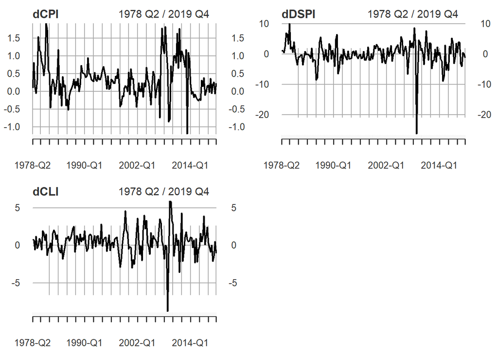

### 6.5 Data in first-difference

The following R chunks performs the ADF test on the first-differenced variables. Because we have taken the first difference, there is no need to include trend option in ADF test.

```r
# After differencing, there should be no deterministic trend in the plots, but it may contain drift terms (especially dealing with non-zero means)
# KPSS test null hypothesis is that variables are stationary with deterministic parts, so just indicate type = "mu"

diff.train$dCPI %>%
  ur.df(type = "drift", selectlags = "AIC") %>%
  summary()
```

```
##
## ###############################################
## # Augmented Dickey-Fuller Test Unit Root Test #
## ###############################################
##
## Test regression drift
##
##
## Call:
## lm(formula = z.diff ~ z.lag.1 + 1 + z.diff.lag)
##
## Residuals:
##      Min       1Q   Median       3Q      Max
## -1.91937 -0.22442 -0.02093  0.17146  1.40266
##
## Coefficients:
##             Estimate Std. Error t value Pr(>|t|)
## (Intercept)  0.14829    0.04435   3.343  0.00103 **
## z.lag.1     -0.44925    0.07963  -5.642 7.34e-08 ***
## z.diff.lag  -0.14575    0.07742  -1.883  0.06156 .
## ---
## Signif. codes:  0 '***' 0.001 '**' 0.01 '*' 0.05 '.' 0.1 ' ' 1
##
## Residual standard error: 0.4522 on 162 degrees of freedom
## Multiple R-squared:  0.2802, Adjusted R-squared:  0.2714
## F-statistic: 31.54 on 2 and 162 DF,  p-value: 2.706e-12
##
##
## Value of test-statistic is: -5.6419 15.9215
##
## Critical values for test statistics:
##       1pct  5pct 10pct
## tau2 -3.46 -2.88 -2.57
## phi1  6.52  4.63  3.81
```

```r
diff.train$dCPI %>%
  ur.kpss(type = "mu", lags = "short") %>%
  summary()
```

```
##
## #######################
## # KPSS Unit Root Test #
## #######################
##
## Test is of type: mu with 4 lags.
##
## Value of test-statistic is: 0.123
##
## Critical value for a significance level of:
##                 10pct  5pct 2.5pct  1pct
## critical values 0.347 0.463  0.574 0.739
```

```r
diff.train$dDSPI %>%
  ur.df(type = "none", selectlags = "AIC") %>%
  summary()
```

```
##
## ###############################################
## # Augmented Dickey-Fuller Test Unit Root Test #
## ###############################################
##
## Test regression none
##
##
## Call:
## lm(formula = z.diff ~ z.lag.1 - 1 + z.diff.lag)
##
## Residuals:
##      Min       1Q   Median       3Q      Max
## -25.4100  -1.4989  -0.0343   2.0070  10.5239
##
## Coefficients:
##            Estimate Std. Error t value Pr(>|t|)
## z.lag.1    -0.89788    0.09277  -9.679   <2e-16 ***
## z.diff.lag  0.21854    0.07642   2.860   0.0048 **
## ---
## Signif. codes:  0 '***' 0.001 '**' 0.01 '*' 0.05 '.' 0.1 ' ' 1
##
## Residual standard error: 3.572 on 163 degrees of freedom
## Multiple R-squared:  0.3986, Adjusted R-squared:  0.3912
## F-statistic: 54.02 on 2 and 163 DF,  p-value: < 2.2e-16
##
##
## Value of test-statistic is: -9.6789
##
## Critical values for test statistics:
##       1pct  5pct 10pct
## tau1 -2.58 -1.95 -1.62
```

```r
diff.train$dDSPI %>%
  ur.kpss(type = "mu", lags = "short") %>%
  summary()
```

```
##
## #######################
## # KPSS Unit Root Test #
## #######################
##
## Test is of type: mu with 4 lags.
##
## Value of test-statistic is: 0.092
##
## Critical value for a significance level of:
##                 10pct  5pct 2.5pct  1pct
## critical values 0.347 0.463  0.574 0.739
```

```r
diff.train$dCLI %>%
  ur.df(type = "drift", selectlags = "AIC") %>%
  summary()
```

```
##
## ###############################################
## # Augmented Dickey-Fuller Test Unit Root Test #
## ###############################################
##
## Test regression drift
##
##
## Call:
## lm(formula = z.diff ~ z.lag.1 + 1 + z.diff.lag)
##
## Residuals:
##     Min      1Q  Median      3Q     Max
## -9.0845 -0.8252  0.0947  0.8918  4.6850
##
## Coefficients:
##             Estimate Std. Error t value Pr(>|t|)
## (Intercept)  0.35903    0.13266   2.706  0.00753 **
## z.lag.1     -0.77113    0.09053  -8.518 1.06e-14 ***
## z.diff.lag   0.14386    0.07797   1.845  0.06685 .
## ---
## Signif. codes:  0 '***' 0.001 '**' 0.01 '*' 0.05 '.' 0.1 ' ' 1
##
## Residual standard error: 1.61 on 162 degrees of freedom
## Multiple R-squared:  0.3495, Adjusted R-squared:  0.3415
## F-statistic: 43.52 on 2 and 162 DF,  p-value: 7.474e-16
##
##
## Value of test-statistic is: -8.5177 36.2797
##
## Critical values for test statistics:
##       1pct  5pct 10pct
## tau2 -3.46 -2.88 -2.57
## phi1  6.52  4.63  3.81
```

```r
diff.train$dCLI %>%
  ur.kpss(type = "mu", lags = "short") %>%
  summary()
```

```
##
## #######################
## # KPSS Unit Root Test #
## #######################
##
## Test is of type: mu with 4 lags.
##
## Value of test-statistic is: 0.0328
##
## Critical value for a significance level of:
##                 10pct  5pct 2.5pct  1pct
## critical values 0.347 0.463  0.574 0.739
```

Since the ADF tau-statistic for all variables are less than the critical tau-value, we can reject the null hypothesis and conclude that the series are I(1) variables (stationary at first difference).

After taking the first difference, we can see that the interaction between variables have changed in the scatterplot matrix and the correlation matrix. This is why stationarity is an important condition as variables may seem to have a relationship at levels but after taking the difference, there may not be a relationship between variables as seen in the scatter plot below.

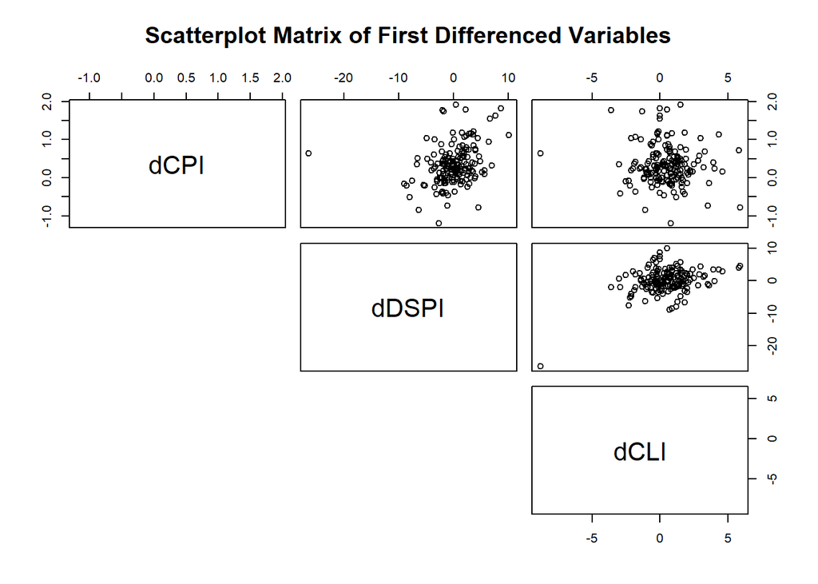

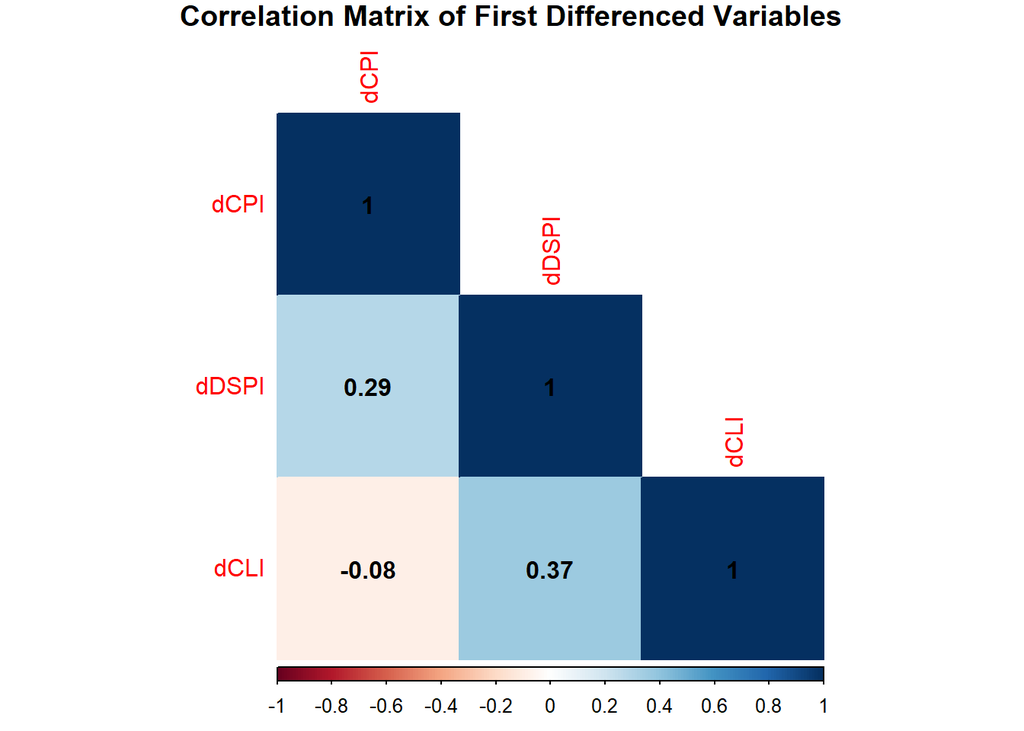

## 7 Model Selection

In this section, I discussed the different possible time series models that can be created from our data.

### 7.1 Autoregressive (Integrated) Moving Average Model

#### 7.1.1 Brief Introduction to ARIMA Models

The AR(I)MA model consists of two parts, an autoregressive (AR) model and a moving average (MA) model. Integrated refers to the number of differencing needed to achieve stationary time series.

An AR(p) model means that $y_t$ depends on p lags of $y$. In other words, we believe that up to the $p$ historical value of $y$ can explain $y_t$. The function is written as:

$$y_t = \alpha + \sum_{i = 1}^p \alpha_i y_{t-i} + u_t$$

A MA(q) model means that $y_t$ depends on q lags of its error terms. In other words, we believe that up to $q$ historical value of $u$ (the error term) can explain $y_t$. The function is written as:

$$y_t = \alpha + u_t + \sum_{j=1}^q \beta_j u_{t-j}$$

An ARMA(p, q) model the combination of AR(p) and MA(q) models. The function is written as:

$$y_t = \alpha + \sum_{i = 1}^p \alpha_i y_{t-i} + u_t + \sum_{j=1}^q
\beta_j u_{t-j}$$

This can be written simply as ARIMA(p, d, q). In Section 6, I had tested that the CPI series is an I(1) series, which means it is stationary at first difference. Therefore, we have an ARIMA(p, 1, q) model. The p and q lags are determined in various ways.

#### 7.1.2 ACF and PACF

Firstly, it is common to use the autocorrelation and partial autocorrelation function to determine the lag order. The functions **`Acf`** and **`Pacf`** in the **`forecast`** package can plot the ACF and PACF.

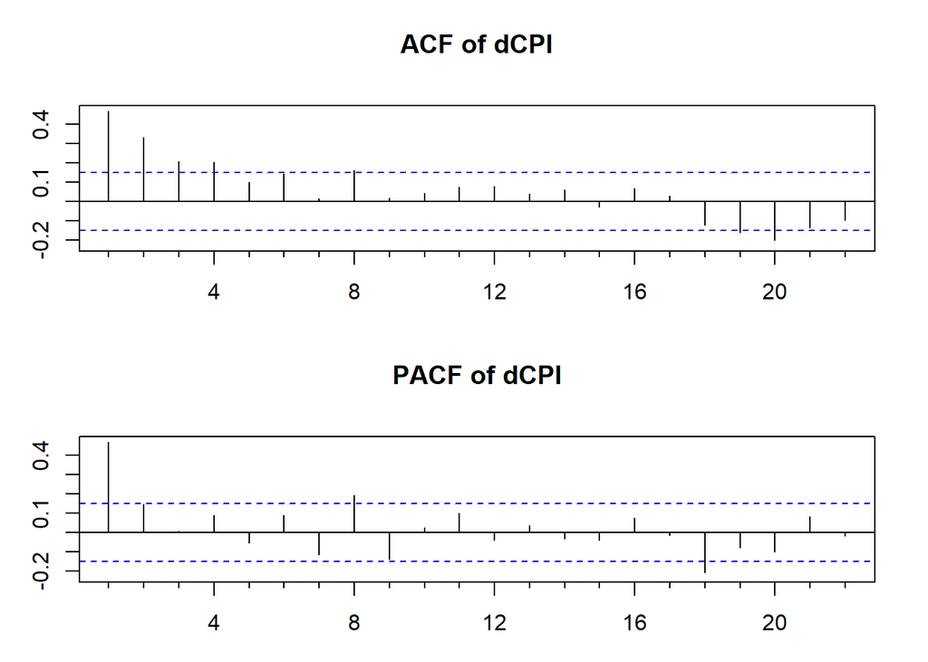

We can gauge/estimate the q lags of the error term using the ACF where spikes are above the blue dotted line and similarly, p lags of the dependent variable using the PACF. Usually, the first spike in the ACF plot refers to lag 0, but the **`forecast`** package removes and we can use the first spike as lag 1 instead. In this case, we might want to try to fit a ARIMA(1, 1, 4) model using the **`Arima`** function in **`forecast`** package.

#### 7.1.3 ARIMA Based on ACF and PACF

```r
# order refers to the (p,d,q) of the ARIMA model
# d = 0 as we are using the differenced data
# method for estimation is to use maximum likelihood

arima1 <- forecast::Arima(diff.train$dCPI,
                          order = c(1, 0, 4),
                          method = "ML")

summary(arima1)
```

```
## Series: diff.train$dCPI
## ARIMA(1,0,4) with non-zero mean
##
## Coefficients:
##          ar1      ma1      ma2      ma3     ma4    mean
##       0.7090  -0.3086  -0.0016  -0.0469  0.0463  0.3328
## s.e.  0.3641   0.3764   0.1639   0.1440  0.0993  0.0809
##
## sigma^2 = 0.2071:  log likelihood = -102.57
## AIC=219.15   AICc=219.85   BIC=240.98
##
## Training set error measures:
##                        ME      RMSE       MAE       MPE     MAPE      MASE
## Training set 0.0008717552 0.4468077 0.3000226 -498.1928 712.1803 0.6590941
##                      ACF1
## Training set 0.0004936192
```

Another method that gets us the same results would be to use the data at levels but indicate `c(1, 1, 4)` in the `order` argument. The benefit of using this method is that the fitted values obtained from the model is automatically corrected to values at levels, instead of first difference. However, other functions used in further sections are mainly based on differenced data as input since we cannot specify a differencing argument in the functions. Therefore, for better comparison, I have decided to use the differenced data here as well.

The output shows the coefficients of the lagged variables in the ARIMA model. It should be noted that the mean value is the mean of the series (not the sample mean, but calculated with the log-likelihood). To convert to the constant value, we multiply the mean by $(1-0.7090)$, which is basically coefficient of the AR terms.

We can write our model as:

$$y_t = 0.097 + 0.7090y_{t-1} - 0.3086u_{t-1} - 0.0016u_{t-2} -
0.0469u_{t-3} + 0.0463u_{t-4}$$

#### 7.1.4 ARIMA Based on AIC

How well does our manually selected model compare against a model selected automatically using the lowest Akaike Information Criterion (AIC)? This is the second method we can use to estimate an ARIMA model, and the **`auto.arima`** function performs the task for us. We have many arguments that we should include: `seasonal` should be set to False since I am not estimating a seasonal ARIMA, `stepwise` and `approximation` should be set to False to obtain a more accurate model selection, `ic` set to AIC, and `trace` set to False to suppress the running of the models by the automatic selection.

```r
arima2 <- forecast::auto.arima(diff.train$dCPI,
                               seasonal = F,
                               ic = "aic",
                               stepwise = F,
                               approximation = F,
                               trace = F,
                               method = "ML")

summary(arima2)
```

```
## Series: diff.train$dCPI
## ARIMA(2,0,1) with non-zero mean
##
## Coefficients:
##           ar1     ar2     ma1    mean
##       -0.3984  0.4993  0.8490  0.3351
## s.e.   0.0922  0.0675  0.0793  0.0699
##
## sigma^2 = 0.2001:  log likelihood = -100.83
## AIC=211.66   AICc=212.03   BIC=227.25
##
## Training set error measures:
##                        ME      RMSE       MAE       MPE   MAPE      MASE
## Training set 0.0004816811 0.4419613 0.3014915 -538.2033 780.46 0.6623209
##                     ACF1
## Training set -0.01233133
```

We can see that the model automatically selected using the lowest AIC is the different from the one I had manually coded into the **`Arima`** function. The `arima2` model had a lower AIC and had a slightly higher log-likelihood than the `arima1` model. I plotted the actual CPI values and the fitted values based on the two ARIMA models to visualize how well the model fits.

#### 7.1.5 Plot Fitted Values

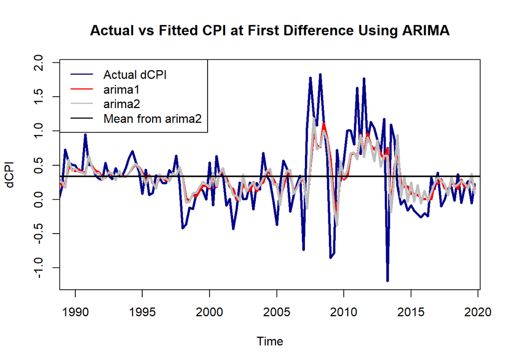

It seems that the `arima1` and `arima2` models approximately captures the pattern (with slight differences), although it does not seem to capture the magnitude of the movements in the CPI that well. ARIMA models can give us a benchmark to compare other types of time series models, either through in-sample prediction or out-of-sample forecast.

### 7.2 Autoregressive Distributed Lag Models

#### 7.2.1 Brief Introduction to ARDL Models

An ARDL model is similar to an ARMA model, except it used the lags of the dependent variables and lags of other explanatory variables to predict $y_t$. ARDL can be used on time series with combinations of I(0) and I(1).

The simplest ARDL model is one with an explanatory ($x$) and a dependent variable ($y$) and the notation for this is ARDL(p, q). Unlike the ARIMA models, an ARDL model allows us to capture the dynamic effects from $x$ to $y$. We can write the model as such:

$$y_t = \alpha + \sum_{i=1}^p \alpha_i y_{t-i} + \sum_{j=0}^q \beta_i
x_{t-i} + \epsilon_t$$

#### 7.2.2 ARDL Model Lag Selection

In our case, we have more than 1 explanatory variables but the same concept applies. We can use the **`auto_ardl`** function in the **`ARDL`** package to automatically select an ARDL model that has the lowest AIC based on a maximum number of lags for the search.

```r
# max_order = 4 to indicate maximum lag in the search for all variables is 4
# possible to state a vector of length equal to no. of variables in max_order
# grid = T to to prevent stepwise search of models

ardl_lag <- ARDL::auto_ardl(formula = dCPI ~ dDSPI + dCLI,
                            data = as.zoo(diff.train),
                            max_order = 4, grid = T,
                            selection = "AIC")

# Obtain the best lag order, arranged by how variables were entered in the formula argument
ardl_lag$best_order
```

```
## [1] 4 1 2
```

```r
# Save the coefficients of the model selected by auto_ardl
ardl <- ardl_lag$best_model

summary(ardl)
```

```
##
## Time series regression with "zoo" data:
## Start = 1979 Q2, End = 2019 Q4
##
## Call:
## dynlm::dynlm(formula = full_formula, data = data, start = start,
##     end = end)
##
## Residuals:
##      Min       1Q   Median       3Q      Max
## -1.96830 -0.19791  0.02277  0.18684  1.22282
##
## Coefficients:
##              Estimate Std. Error t value Pr(>|t|)
## (Intercept)  0.096906   0.046950   2.064  0.04070 *
## L(dCPI, 1)   0.257084   0.077079   3.335  0.00107 **
## L(dCPI, 2)   0.192362   0.074942   2.567  0.01122 *
## L(dCPI, 3)   0.012879   0.075414   0.171  0.86463
## L(dCPI, 4)   0.175960   0.069773   2.522  0.01270 *
## dDSPI        0.039020   0.009285   4.203 4.47e-05 ***
## L(dDSPI, 1)  0.027543   0.009935   2.772  0.00626 **
## dCLI        -0.040132   0.021843  -1.837  0.06811 .
## L(dCLI, 1)   0.056782   0.022624   2.510  0.01312 *
## L(dCLI, 2)   0.032457   0.020753   1.564  0.11989
## ---
## Signif. codes:  0 '***' 0.001 '**' 0.01 '*' 0.05 '.' 0.1 ' ' 1
##
## Residual standard error: 0.3893 on 153 degrees of freedom
## Multiple R-squared:  0.467,  Adjusted R-squared:  0.4357
## F-statistic:  14.9 on 9 and 153 DF,  p-value: < 2.2e-16
```

Unlike the ARIMA output earlier, the ARDL output does not state the log-likelihood or the AIC values. This can be found using the **`logLik`** and **`AIC`** functions in base R.

```r
logLik(ardl)
```

```
## 'log Lik.' -72.3627 (df=11)
```

```r
AIC(ardl)
```

```
## [1] 166.7254
```

#### 7.2.3 Plot Fitted Values

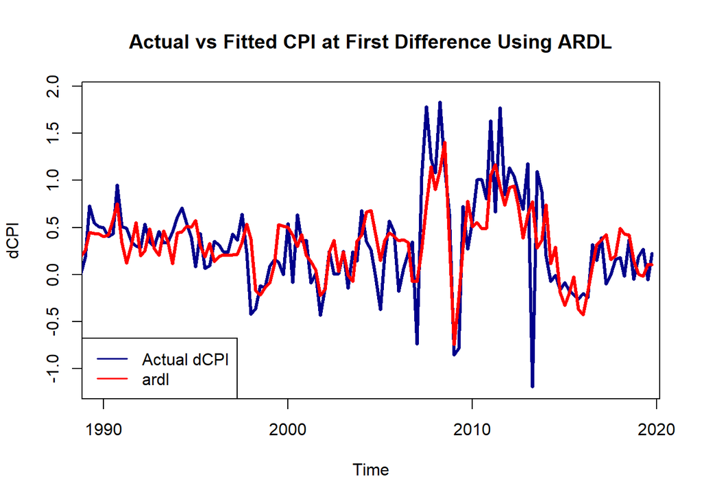

### 7.3 Vector Autoregressive Model

#### 7.3.1 Brief Introduction to VAR Models

We can see that with more lags and more variables included into the VAR system, there would be more unknown parameters and lesser degrees of freedom, which can affect estimation and statistical tests. However, if too few lags were included, we may encounter the problem of autocorrelated errors.

#### 7.3.2 VAR Model Lag Selection

To build a VAR model, we first need to determine the optimal number of lags which can be done by using the **`VARselect`** function in the **`vars`** package.

```r
var_lag <- vars::VARselect(y = diff.train,
                           lag.max = 4,
                           type = "const")

var_lag
```

```
## $selection
## AIC(n)  HQ(n)  SC(n) FPE(n)
##      2      2      1      2
##
## $criteria
##               1        2        3        4
## AIC(n) 1.650474 1.573553 1.615502 1.616389
## HQ(n)  1.742942 1.735373 1.846673 1.916911
## SC(n)  1.878234 1.972135 2.184904 2.356612
## FPE(n) 5.209601 4.824523 5.032743 5.040008
```

#### 7.3.3 Estimate VAR Equations

Based on AIC, I would choose to use 2 lag for the VAR model, i.e. VAR(2) model. We could use the SC (or BIC) selected lags for a parsimonious model. The function **`VAR`** in the **`vars`** package allows us to estimate this model.

```r
var <- vars::VAR(y = diff.train,
                 p = 2,
                 type = "const")

stargazer(var$varresult,
          type = "text",
          title = "VAR Estimation Result for dCPI, dDSPI, dCLI",
          digits = 3,
          column.labels = c("dCPI", "dDSPI", "dCLI"),
          dep.var.labels.include = F)
```

```
##
## VAR Estimation Result for dCPI, dDSPI, dCLI
## ============================================================
##                                     Dependent variable:
##                                -----------------------------
##                                   dCPI      dDSPI     dCLI
##                                   (1)        (2)      (3)
## ------------------------------------------------------------
## dCPI.l1                         0.268***   -0.393    -0.051
##                                 (0.080)    (0.694)  (0.301)
##
## dDSPI.l1                        0.041***  0.342***   -0.039
##                                 (0.010)    (0.088)  (0.038)
##
## dCLI.l1                          0.039*    -0.079   0.346***
##                                 (0.023)    (0.196)  (0.085)
##
## dCPI.l2                         0.261***    0.385    -0.381
##                                 (0.075)    (0.652)  (0.283)
##
## dDSPI.l2                         -0.004   -0.276*** -0.086**
##                                 (0.010)    (0.091)  (0.039)
##
## dCLI.l2                          0.032     0.358*    -0.061
##                                 (0.023)    (0.196)  (0.085)
##
## const                           0.120***   -0.103   0.484***
##                                 (0.046)    (0.396)  (0.172)
##
## ------------------------------------------------------------
## Observations                      165        165      165
## R2                               0.382      0.133    0.200
## Adjusted R2                      0.358      0.100    0.170
## Residual Std. Error (df = 158)   0.414      3.589    1.558
## F Statistic (df = 6; 158)      16.250***  4.030***  6.590***
## ============================================================
## Note:                            *p<0.1; **p<0.05; ***p<0.01
```

The output shows the three equations, one for each variable, with 2 lags of each variable. Therefore, the model gets really big as more variables and lags are added, which can become a problem. We can write it down as:

$$
$$\begin{aligned}
\Delta CPI_t &= 0.120 + 0.268\Delta CPI_{t-1} + 0.261\Delta
CPI_{t-2} + 0.041\Delta DSPI_{t-1} - 0.004\Delta DSPI_{t-2} +
0.039\Delta CLI_{t-1} + 0.032\Delta CLI_{t-2} \\
\Delta DSPI_t &= -0.103 + 0.342\Delta DSPI_{t-1} - 0.276\Delta
DSPI_{t-2} - 0.393\Delta CPI_{t-1} + 0.385\Delta CPI_{t-2} - 0.079\Delta
CLI_{t-1} + 0.358\Delta CLI_{t-2} \\
\Delta CLI_t &= 0.484 + 0.346\Delta CLI_{t-1} - 0.061\Delta
CLI_{t-2} - 0.039\Delta DSPI_{t-1} - 0.086\Delta DSPI_{t-2} -
0.051\Delta CPI_{t-1} - 0.381\Delta CPI_{t-2}
\end{aligned}$$

#### 7.3.4 Plot Fitted Values

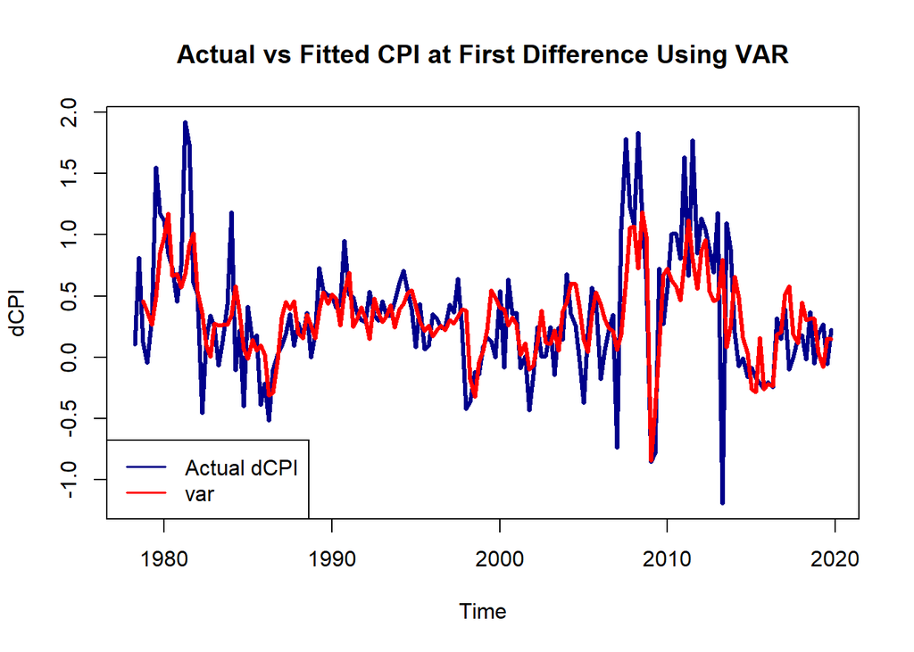

An advantage of models like VAR is that we can also plot the predicted values of other variables that are in the model.

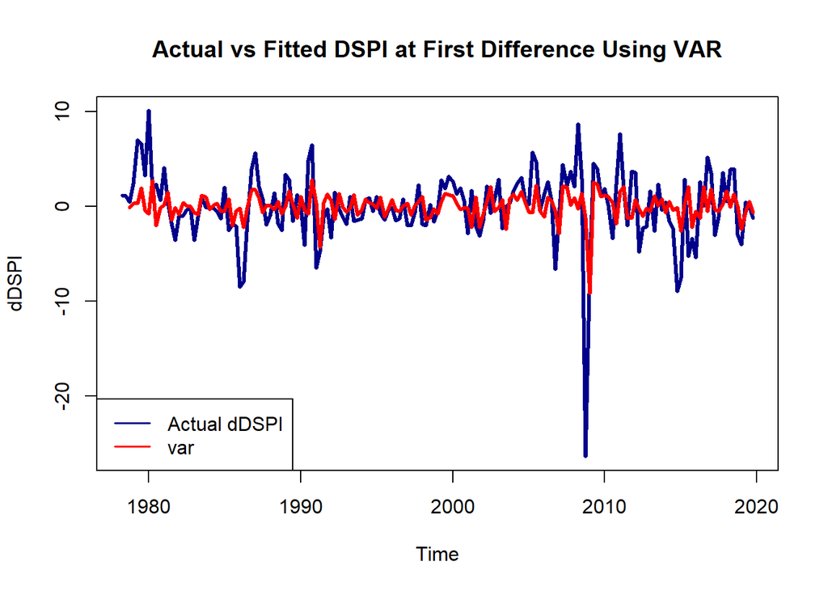

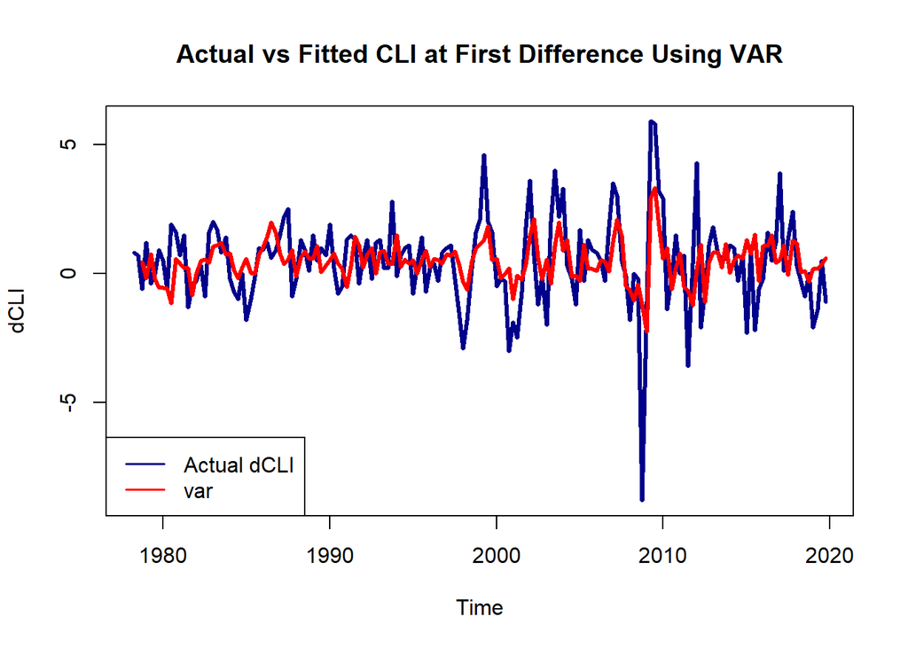

## 8 Granger Causality Test

Using the Granger Causality Test, we can statistically determine if a series can be used predict values of another series better than solely using its past values. Despite the name, it should not be used to determine true cause-and-effect relationships between variables. It can be a useful test to determine if variables should be added to a time series model to improve forecasting accuracy.

In simple terms, the Granger Causality Test checks if the lags of variable $x$ can be used to improve the forecast of variable 2 than solely basing on the lags of variable $y$. What the test does is to apply a Likelihood Ratio Test or a F-Test on the two models below. The null hypothesis is that $x$ does not granger-cause $y$, against the alternative that $x$ granger-causes $y$.

$$\begin{aligned}
y_t &= \theta_0 + \theta_1 y_{t-1} + \gamma_1 x_{t-1} + e_t \\
y_t &= \theta_0 + \theta_1 y_{t-1} + e_t
\end{aligned}$$

With two variables, we can test if $x$ granger-causes $y$, $y$ granger-causes $x$ or if there is bi-directional granger causality between $x$ and $y$. The set up would start to look like a VAR model, and there is indeed a package called **`bruceR`** that uses a VAR output to perform this test using the function **`granger_test`** for bivariate models and **`granger_causality`** for multivariate models.

```r
granger_causality(varmodel = var)
```

```
##
## Granger Causality Test (Multivariate)
##
## F test and Wald χ² test based on VAR(2) model:
## ───────────────────────────────────────────────────────────
##                      F df1 df2     p     Chisq df     p
## ───────────────────────────────────────────────────────────
##  -------------
##  dCPI <= dDSPI    8.25   2 158 <.001 *** 16.50  2 <.001 ***
##  dCPI <= dCLI     3.87   2 158  .023 *    7.74  2  .021 *
##  dCPI <= ALL      8.92   4 158 <.001 *** 35.69  4 <.001 ***
##  -------------
##  dDSPI <= dCPI    0.23   2 158  .792      0.47  2  .792
##  dDSPI <= dCLI    1.70   2 158  .185      3.41  2  .182
##  dDSPI <= ALL     0.87   4 158  .484      3.48  4  .481
##  -------------
##  dCLI <= dCPI     1.25   2 158  .288      2.51  2  .286
##  dCLI <= dDSPI    3.57   2 158  .030 *    7.14  2  .028 *
##  dCLI <= ALL      3.76   4 158  .006 **  15.04  4  .005 **
## ───────────────────────────────────────────────────────────
```

## 9 Cointegration

### 9.1 Johansen Test

Since we have I(1) variables, we can model the variables at levels if they are found to have a cointegrating relationship. When variables are cointegrated, they appear to have the same long-run patterns and the difference between these two variables are stationary. In such cases, we could estimate a Error Correction Model (ECM) or a Vector Error Correction Model (VECM), which allows us to model long-run relationships between variables. If these I(1) variables are not cointegrated, we can only estimate a short-run model using the VAR or ARDL models.

To test for cointegration of multivariate time series, I have used the Johansen Test using the **`ca.jo`** function in the **`urca`** package. One of the arguments required is to specify the lag order of the level series in the VAR model. This can be determined using the **`VARselect`** function in the **`vars`** package.

```r
# Use the data at levels, not at first difference
lagselect <- vars::VARselect(train, lag.max = 4, type = "const")

lagselect$selection
```

```
## AIC(n)  HQ(n)  SC(n) FPE(n)
##      3      2      2      3
```

To be constant throughout the project, I would use the AIC to select the number of lags. The `lagselect` output indicated we should use 3 lags for the Johansen Test.

```r
# Indicate type = "trace" for trace test, "eigen" for eigenvalue test

# Indicate ecdet = "none" assuming no intercept in the cointegration process, indicate "const" or "trend" to add constant or trend into the equation
# It is common to indicate no deterministic terms in the error correction term unless there are reasons to believe otherwise

# K is the number of lags from the lag selection using VARselect

jotest <- urca::ca.jo(x = train,
                      type = "trace",
                      ecdet = "none",
                      K = 3)

summary(jotest)
```

```
##
## ######################
## # Johansen-Procedure #
## ######################
##
## Test type: trace statistic , with linear trend
##
## Eigenvalues (lambda):
## [1] 0.112648456 0.097619805 0.005873078
##
## Values of teststatistic and critical values of test:
##
##           test 10pct  5pct  1pct
## r <= 2 |  0.97  6.50  8.18 11.65
## r <= 1 | 17.92 15.66 17.95 23.52
## r = 0  | 37.64 28.71 31.52 37.22
##
## Eigenvectors, normalised to first column:
## (These are the cointegration relations)
##
##             CPI.l3    DSPI.l3    CLI.l3
## CPI.l3   1.0000000  1.0000000  1.000000
## DSPI.l3  0.3407136 -0.2576423  1.229929
## CLI.l3  -0.5627592 -0.6376516 -5.011137
##
## Weights W:
## (This is the loading matrix)
##
##               CPI.l3     DSPI.l3       CLI.l3
## CPI.d  -0.0004640629 -0.03969217 2.872257e-05
## DSPI.d -0.2221608552 -0.07743235 7.697682e-04
## CLI.d  -0.0092783984  0.01652976 1.029779e-03
```

The test results are read starting from:

1. r = 0: value under test column is more than value under 5pct column (statistically significant) and we have at least one cointegrating relationship.
2. r <= 1: value under test column is less than value under 5pct column (statistically insignificant) and we have at most one cointegrating relationship.

Since we have found evidence of cointegration through the Johansen Test, we can estimate a ECM or VECM model.

### 9.2 Error Correction Model

#### 9.2.1 Steps to Estimating ECM

Given the cointegration between variables, we can model the long-run equilibrium variable $y^*$ using the equilibrium of $x^*$ at levels. To model the short-run model, we need to remember that the variables are I(1), so we need to use a first-differenced equation, for example $\Delta y_t = \gamma_0 + \gamma_1 \Delta x_t + \epsilon_t$. But since there is a long-run association between $y$ and $x$, we could include some components into the short-run model so that it takes into account this long-run association. What we can add into the short-run model is the error correction term (ECT), which is the one-period ago residual from the long-run model. The following are the steps to modelling an ECM:

1. Regress $y^*$ on $x^*$ (and their lags) and obtain the residuals $v_t$
2. Regress $\Delta y_t$ on $\Delta x_t$ and the lag of the residual in Step 1, $v_{t-1}$

If there is indeed cointegration, the coefficient of $v_{t-1}$ should be between -1 and 0. This is because, taking the long-run pattern into account, if $y_{t-1}$ was above/below $y^*$, then we should expect $y_t$ to decrease/increase, showing an adjustment to the equilibrium.

#### 9.2.2 Estimate ARDL at level

Let us first estimate a model in levels as per step one using **`auto_ardl`**

```r
ardl_lr_lag <- ARDL::auto_ardl(formula = CPI ~ DSPI + CLI,
                               data = as.zoo(train),
                               max_order = 4,
                               selection = "AIC",
                               grid = T)

ardl_lr <- ardl_lr_lag$best_model

summary(ardl_lr)
```

```
##
## Time series regression with "zoo" data:
## Start = 1978 Q4, End = 2019 Q4
##
## Call:
## dynlm::dynlm(formula = full_formula, data = data, start = start,
##     end = end)
##
## Residuals:
##     Min      1Q  Median      3Q     Max
## -1.7297 -0.2122  0.0080  0.2073  1.1320
##
## Coefficients:
##              Estimate Std. Error t value Pr(>|t|)
## (Intercept) -0.119847   0.442929  -0.271  0.78708
## L(CPI, 1)    1.166220   0.077287  15.089  < 2e-16 ***
## L(CPI, 2)   -0.070034   0.117069  -0.598  0.55056
## L(CPI, 3)   -0.126197   0.072143  -1.749  0.08223 .
## DSPI         0.036974   0.009367   3.947  0.00012 ***
## L(DSPI, 1)  -0.006121   0.014886  -0.411  0.68151
## L(DSPI, 2)  -0.018865   0.009706  -1.944  0.05376 .
## CLI         -0.031103   0.020905  -1.488  0.13884
## L(CLI, 1)    0.090332   0.033457   2.700  0.00771 **
## L(CLI, 2)   -0.039690   0.021399  -1.855  0.06553 .
## ---
## Signif. codes:  0 '***' 0.001 '**' 0.01 '*' 0.05 '.' 0.1 ' ' 1
##
## Residual standard error: 0.3793 on 155 degrees of freedom
## Multiple R-squared:  0.9994, Adjusted R-squared:  0.9994
## F-statistic: 3.057e+04 on 9 and 155 DF,  p-value: < 2.2e-16
```

#### 9.2.3 Obtain ECM Equation

Instead of extracting the residuals, we can use the **`uecm`** and **`recm`** functions to get the unrestricted and restricted form of the ECM. The first model will show all the coefficients with the long-run and short-run variables, while the second will only show the short-run variables with the ECT.

```r
un_ecm <- ARDL::uecm(ardl_lr)

summary(un_ecm)
```

```
##
## Time series regression with "zoo" data:
## Start = 1978 Q4, End = 2019 Q4
##
## Call:
## dynlm::dynlm(formula = full_formula, data = data, start = start,
##     end = end)
##
## Residuals:
##     Min      1Q  Median      3Q     Max
## -1.7297 -0.2122  0.0080  0.2073  1.1320
##
## Coefficients:
##                Estimate Std. Error t value Pr(>|t|)
## (Intercept)   -0.119847   0.442929  -0.271  0.78708
## L(CPI, 1)     -0.030011   0.010889  -2.756  0.00655 **
## L(DSPI, 1)     0.011989   0.003216   3.728  0.00027 ***
## L(CLI, 1)      0.019538   0.006821   2.865  0.00475 **
## d(L(CPI, 1))   0.196231   0.074311   2.641  0.00912 **
## d(L(CPI, 2))   0.126197   0.072143   1.749  0.08223 .
## d(DSPI)        0.036974   0.009367   3.947  0.00012 ***
## d(L(DSPI, 1))  0.018865   0.009706   1.944  0.05376 .
## d(CLI)        -0.031103   0.020905  -1.488  0.13884
## d(L(CLI, 1))   0.039690   0.021399   1.855  0.06553 .
## ---
## Signif. codes:  0 '***' 0.001 '**' 0.01 '*' 0.05 '.' 0.1 ' ' 1
##
## Residual standard error: 0.3793 on 155 degrees of freedom
## Multiple R-squared:  0.4898, Adjusted R-squared:  0.4602
## F-statistic: 16.54 on 9 and 155 DF,  p-value: < 2.2e-16
```

`L(CPI, 1)` is the lag of our dependent variable and its coefficient is actually the ECT, which tells us how `CPI` would react given a shock to `L(CPI, 1)`. `L(DSPI, 1)` and `L(CLI, 1)` is the long-run coefficient (after some conversion) and the differenced variables (those starting with `d...`) are the short-run coefficients.

```r
# Indicated case = 3 to include constant in the model
r_ecm <- ARDL::recm(un_ecm, case = 3)

summary(r_ecm)
```

```
##
## Time series regression with "zooreg" data:
## Start = 1978 Q4, End = 2019 Q4
##
## Call:
## dynlm::dynlm(formula = full_formula, data = data, start = start,
##     end = end)
##
## Residuals:
##     Min      1Q  Median      3Q     Max
## -1.7297 -0.2122  0.0080  0.2073  1.1320
##
## Coefficients:
##                Estimate Std. Error t value Pr(>|t|)
## (Intercept)   -0.119847   0.074168  -1.616  0.10812
## d(L(CPI, 1))   0.196231   0.073783   2.660  0.00864 **
## d(L(CPI, 2))   0.126197   0.070983   1.778  0.07737 .
## d(DSPI)        0.036974   0.008794   4.204 4.38e-05 ***
## d(L(DSPI, 1))  0.018865   0.009622   1.961  0.05170 .
## d(CLI)        -0.031103   0.020452  -1.521  0.13032
## d(L(CLI, 1))   0.039690   0.020853   1.903  0.05883 .
## ect           -0.030011   0.007082  -4.238 3.84e-05 ***
## ---
## Signif. codes:  0 '***' 0.001 '**' 0.01 '*' 0.05 '.' 0.1 ' ' 1
##
## Residual standard error: 0.3768 on 157 degrees of freedom
##   (0 observations deleted due to missingness)
## Multiple R-squared:  0.4898, Adjusted R-squared:  0.4671
## F-statistic: 21.53 on 7 and 157 DF,  p-value: < 2.2e-16
```

We can see that the `r_ecm` output is the same as the `un_ecm` output, less the long-run variables. And as expected, the ECT is negative and is between -1 and 0 (and statistically significant).

To obtain the long-run multiplier, we can use the **`multiplier`** function.

```r
stargazer(multipliers(un_ecm), # Can also be used on ardl_lr
          type = "text",
          title = "Long Run Multipliers of var Model",
          summary = F)
```

```
##
## Long Run Multipliers of var Model
## ====================================================
##      term     estimate std.error t.statistic p.value
## ----------------------------------------------------
## 1 (Intercept)  -3.993   15.733     -0.254     0.800
## 2    DSPI      0.399     0.159      2.510     0.013
## 3     CLI      0.651     0.043     15.274       0
## ----------------------------------------------------
```

The equation of the error correction model is:

$$
$$\begin{aligned}
\Delta CPI_t = &-0.119 + 0.196\Delta CPI_{t-1} + 0.126\Delta
CPI_{t-2} + 0.036\Delta DSPI_t \\
& + 0.018\Delta DSPI_{t-1} - 0.031\Delta CLI_{t} + 0.039\Delta
CLI_{t-1} - 0.030ECT_{t-1}
\end{aligned}$$

$$

#### 9.2.4 Plot Fitted Values

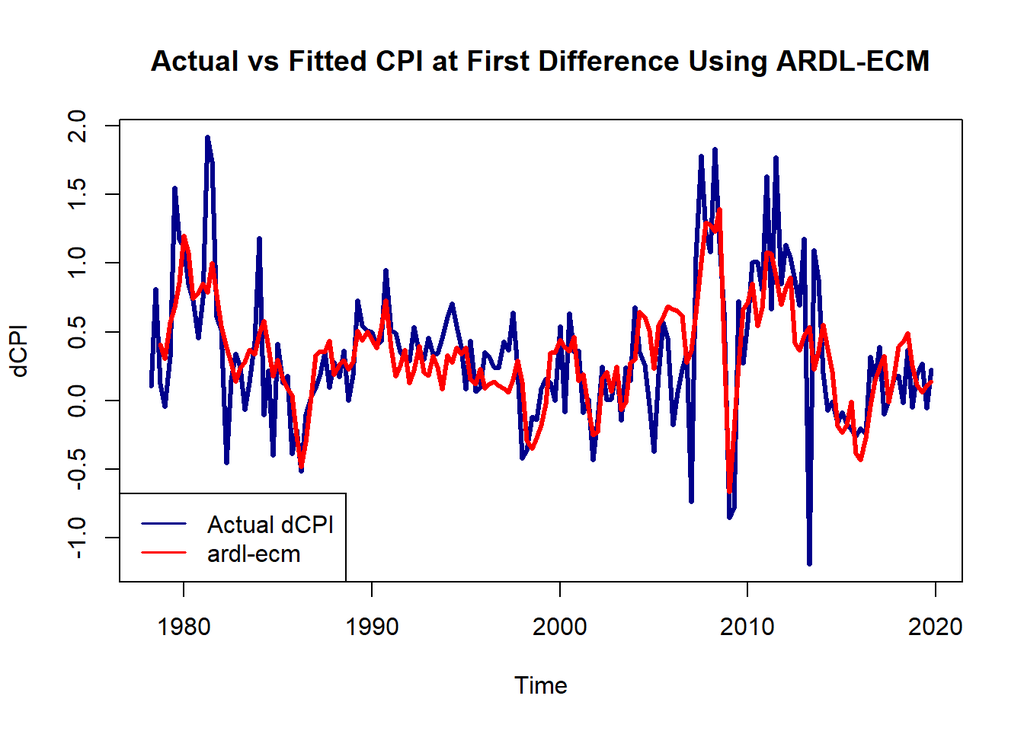

### 9.3 Vector Error Correction Model

#### 9.3.1 Estimating VECM Equations

We can build a VECM using the **`urca`** package, using the functions **`ca.jo`**, **`cajools`** and **`cajorls`**. Although we had seen earlier in the Johansen Test that we used **`ca.jo`** to test the number of cointegrating relationships, it can also provide the VECM using the other functions mentioned.

```r
# K = 3 was determined in Section 9 in the Johansen Test
# Add in spec = "transitory" to obtain the VECM formula

get_vecm <- ca.jo(x = train,
                  type = "trace",
                  ecdet = "none",
                  K = 3,
                  spec = "transitory")


# Get estimated VAR parameters
# r represents number of cointegrations

vec_ecm <- cajorls(get_vecm, r = 1)

kable(tidy(summary(vec_ecm$rlm)[[1]]), format = "pipe",
      caption = "VECM Estimation Output for dCPI",
      digits = 4)
```

VECM Estimation Output for dCPI

| term | estimate | std.error | statistic | p.value |
| --- | --- | --- | --- | --- |
| ect1 | -0.0005 | 0.0066 | -0.0702 | 0.9442 |
| constant | 0.1526 | 0.4669 | 0.3270 | 0.7441 |
| CPI.dl1 | 0.2691 | 0.0817 | 3.2926 | 0.0012 |
| DSPI.dl1 | 0.0406 | 0.0102 | 3.9737 | 0.0001 |
| CLI.dl1 | 0.0391 | 0.0227 | 1.7260 | 0.0863 |
| CPI.dl2 | 0.2616 | 0.0766 | 3.4138 | 0.0008 |
| DSPI.dl2 | -0.0038 | 0.0105 | -0.3607 | 0.7188 |
| CLI.dl2 | 0.0314 | 0.0230 | 1.3683 | 0.1732 |

```r
kable(tidy(summary(vec_ecm$rlm)[[2]]), format = "pipe",
      caption = "VECM Estimation Output for dDSPI",
      digits = 4)
```

VECM Estimation Output for dDSPI

| term | estimate | std.error | statistic | p.value |
| --- | --- | --- | --- | --- |
| ect1 | -0.2222 | 0.0546 | -4.0690 | 0.0001 |
| constant | 15.5003 | 3.8532 | 4.0227 | 0.0001 |
| CPI.dl1 | 0.1272 | 0.6745 | 0.1886 | 0.8507 |
| DSPI.dl1 | 0.3030 | 0.0843 | 3.5919 | 0.0004 |
| CLI.dl1 | -0.1062 | 0.1871 | -0.5677 | 0.5710 |
| CPI.dl2 | 0.8377 | 0.6324 | 1.3247 | 0.1872 |
| DSPI.dl2 | -0.2986 | 0.0867 | -3.4457 | 0.0007 |
| CLI.dl2 | 0.2283 | 0.1895 | 1.2046 | 0.2302 |

```r
kable(tidy(summary(vec_ecm$rlm)[[3]]), format = "pipe",
      caption = "VECM Estimation Output for dCLI",
      digits = 4)
```

VECM Estimation Output for dCLI

| term | estimate | std.error | statistic | p.value |
| --- | --- | --- | --- | --- |
| ect1 | -0.0093 | 0.0249 | -0.3726 | 0.7100 |
| constant | 1.1357 | 1.7576 | 0.6461 | 0.5191 |
| CPI.dl1 | -0.0291 | 0.3077 | -0.0944 | 0.9249 |
| DSPI.dl1 | -0.0405 | 0.0385 | -1.0520 | 0.2944 |
| CLI.dl1 | 0.3452 | 0.0853 | 4.0448 | 0.0001 |
| CPI.dl2 | -0.3617 | 0.2885 | -1.2538 | 0.2118 |
| DSPI.dl2 | -0.0865 | 0.0395 | -2.1872 | 0.0302 |
| CLI.dl2 | -0.0660 | 0.0864 | -0.7638 | 0.4461 |

The output shows the coefficients under the `estimate` column of each variable under the `term` column. The 3 equations in the VECM are:

$$
$$\begin{aligned}
\Delta CPI_t &= 0.1526 + 0.2691\Delta CPI_{t-1} + 0.2616\Delta
CPI_{t-2} + 0.0406 \Delta DSPI_{t-1} -0.003\Delta DSPI_{t-2} \\
&~~~~
+ 0.0391\Delta CLI_{t-1} + 0.0314\Delta CLI_{t-2} - 0.0005 ECT_{t-1} \\
\Delta DSPI_t &= 15.5003 + 0.1272\Delta CPI_{t-1} + 0.8377\Delta
CPI_{t-2} + 0.3030\Delta DSPI_{t-1} -0.2986\Delta DSPI_{t-2} \\
&~~~~
-0.1062\Delta CLI_{t-1} + 0.2283\Delta CLI_{t-2} -0.2222 ECT_{t-1} \\
\Delta CLI_t &= 1.1357 -0.0291\Delta CPI_{t-1} -0.3617\Delta
CPI_{t-2} -0.0405\Delta DSPI_{t-1} -0.0865\Delta DSPI_{t-2} \\
&~~~~
+0.3452\Delta CLI_{t-1} -0.0660\Delta CLI_{t-2} -0.0093 ECT_{t-1}
\end{aligned}$$

$$

#### 9.3.2 Plot Fitted Values

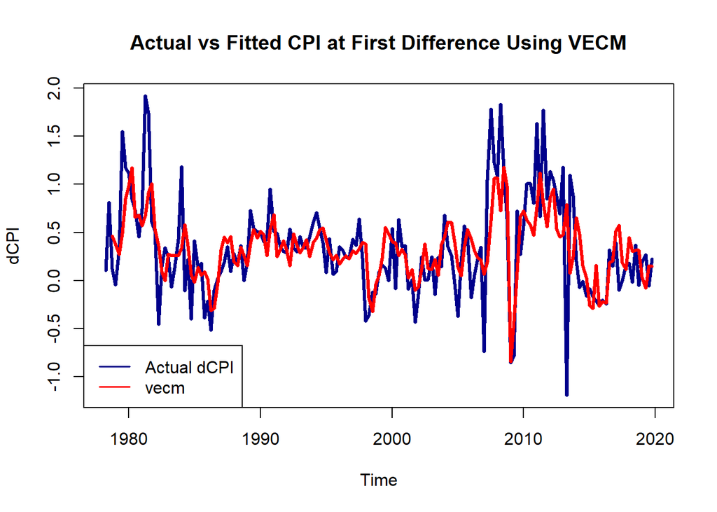

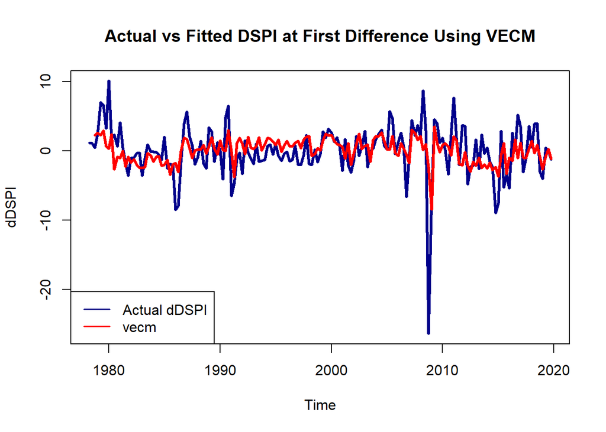

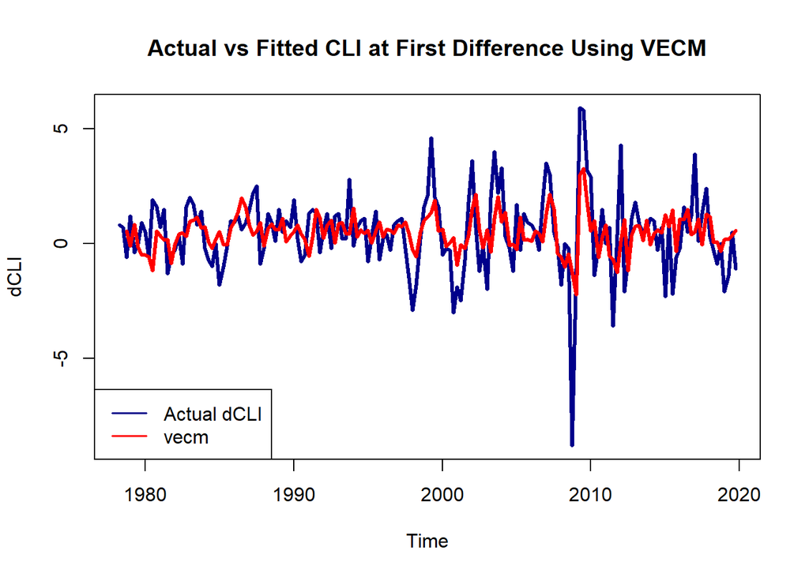

We can also convert the VECM in differences to a VAR in levels using the **`vec2var`** function, which is particularly useful when we are forecasting since it gives us the output in levels.

```r
var_ecm <- vec2var(get_vecm, r = 2)

var_ecm
```

```
##
## Coefficient matrix of lagged endogenous variables:
##
## A1:
##           CPI.l1     DSPI.l1     CLI.l1
## CPI   1.14854574  0.04091275 0.04770292
## DSPI -0.32920007  1.22816711 0.03501547
## CLI   0.01166646 -0.04382656 1.34696558
##
##
## A2:
##           CPI.l2     DSPI.l2       CLI.l2
## CPI  -0.02508445 -0.03874531 -0.007197675
## DSPI  0.67623129 -0.59052287  0.335495327
## CLI  -0.32528719 -0.04833322 -0.411441590
##
##
## A3:
##          CPI.l3     DSPI.l3      CLI.l3
## CPI  -0.1636175 0.007900839 -0.01493431
## DSPI -0.6466244 0.306612375 -0.19611287
## CLI   0.3208721 0.084739736  0.05915729
##
##
## Coefficient matrix of deterministic regressor(s).
##
##        constant
## CPI   0.4005884
## DSPI 15.9839561
## CLI   1.0323983
```

## 10 Post-Estimation Tests

Two common problems encountered in time series analysis are serial correlation of errors and heteroskedastic errors. These can affect our analysis as estimators are no longer efficient and the usual test statistics become unreliable, which can be important if inference is the main purpose. The Breusch-Godfrey Test can be used to test for serial correlation, while the Breusch-Pagan Test can be used to test for heteroskedasticity. However, there is no single package that could accommodate different models for these tests, so we will have to use different functions from different packages for the models that are accepted.

However, using Newey-West standard errors to obtain the corrected test statistics regardless of whether serial correlation and/or heteroskedasticity is present seems to be an acceptable method, especially when we have large sample sizes.

### 10.1 ARDL Model

We can use the **`bgtest`** and **`bptest`** from the **`lmtest`** package.

```r
# Test with up to 4 lags of the residuals

lmtest::bgtest(ardl, order = 4)
```

```
##
##  Breusch-Godfrey test for serial correlation of order up to 4
##
## data:  ardl
## LM test = 10.169, df = 4, p-value = 0.03767
```

```r
lmtest::bptest(ardl, studentize = T)
```

```
##
##  studentized Breusch-Pagan test
##
## data:  ardl
## BP = 18.642, df = 9, p-value = 0.02842
```

There is serial correlation and heteroskedasticity in the ARDL residuals, and we should use the Newey-West (Heteroskedasticity and Autocorrelation Corrected) standard errors to obtain the correct test statistics for inference.

### 10.2 VAR Model

The functions that can be applied to VAR models are **`serial.test`** and the **`arch.test`** from the **`vars`** package. The **`arch.test`** performs the ARCH test to detect if there is changing conditional variance in a time series, unlike the Breusch-Pagan test that detects for constant variance.

```r
vars::serial.test(var, lags.bg = 4, type = "BG")
```

```
##
##  Breusch-Godfrey LM test
##
## data:  Residuals of VAR object var
## Chi-squared = 37.111, df = 36, p-value = 0.4176
```

```r
vars::arch.test(var, lags.single = 4, lags.multi = 4, multivariate.only = F)
```

```
## $dCPI
##
##  ARCH test (univariate)
##
## data:  Residual of dCPI equation
## Chi-squared = 11.411, df = 4, p-value = 0.02232
##
##
## $dDSPI
##
##  ARCH test (univariate)
##
## data:  Residual of dDSPI equation
## Chi-squared = 1.9459, df = 4, p-value = 0.7457
##
##
## $dCLI
##
##  ARCH test (univariate)
##
## data:  Residual of dCLI equation
## Chi-squared = 3.2084, df = 4, p-value = 0.5236
##
##
##
##  ARCH (multivariate)
##
## data:  Residuals of VAR object var
## Chi-squared = 195.17, df = 144, p-value = 0.002925
```

From the tests, there are was no serial correlation detected at up to 4 lags of the error term, and only `dCPI` and the overall VAR models has ARCH effects.

### 10.3 VECM

```r
vars::serial.test(var_ecm, lags.bg = 4, type = "BG")
```

```
##
##  Breusch-Godfrey LM test
##
## data:  Residuals of VAR object var_ecm
## Chi-squared = 32.422, df = 36, p-value = 0.6395
```

```r
vars::arch.test(var_ecm, lags.single = 4, lags.multi = 4, multivariate.only = F)
```

```
## $`resids of CPI`
##
##  ARCH test (univariate)
##
## data:  Residual of resids of CPI equation
## Chi-squared = 15.957, df = 4, p-value = 0.003077
##
##
## $`resids of DSPI`
##
##  ARCH test (univariate)
##
## data:  Residual of resids of DSPI equation
## Chi-squared = 1.4143, df = 4, p-value = 0.8417
##
##
## $`resids of CLI`
##
##  ARCH test (univariate)
##
## data:  Residual of resids of CLI equation
## Chi-squared = 3.571, df = 4, p-value = 0.4672
##
##
##
##  ARCH (multivariate)
##
## data:  Residuals of VAR object var_ecm
## Chi-squared = 209.8, df = 144, p-value = 0.0002854
```

Similar to the tests for the VAR model, there is no serial correlation detected at up to 4 lags of the error terms and only the `CPI` single equation and the multivariate model has ARCH effects.

## 11 Forecasting and Evaluation

### 11.1 Forecasting Details

For the forecast and evaluation, I would compare the data at first difference in the `diff.test` dataset against the 8 period ahead forecasted values. This would mean that the forecasted values are for the periods 2020 Q1 to 2021 Q4. I then plotted the actual vs forecasted values at levels to see how well the different models fit. However, there are two points to keep in mind.

Firstly, the forecasted values will be in first-difference. Conversion to levels can be done simply by adding the cumulative forecasted values to the last observation used in the `diff.train` dataset.

Secondly, models such as ARIMA and VAR uses endogenous variable but ARDL models contains exogenous variables. This means that we would need data on the exogenous variables in the ARDL models for the forecasting to work. Such data can be obtained through the use of ARIMA models to forecast exogenous variables before inputting them into the ARDL forecast. However, for simplicity, I would use the data in the `diff.test` set to compare the performance of the ARDL and ARDL-EC models while ARIMA and VAR/VECM would be compared to one another.

### 11.2 Forecast Performance of ARIMA Models

```r
arima1_h8 <- forecast(object = arima1, h = 8, level = 95)

stargazer(as.data.frame(arima1_h8),
          type = "text",
          title = "Forecasted dCPI 2020Q1 to 2021Q4 Using arima1 Model",
          summary = F)
```

```
##
## Forecasted dCPI 2020Q1 to 2021Q4 Using arima1 Model
## =================================
##       Point Forecast Lo 95  Hi 95
## ---------------------------------
## 42 Q4     0.232      -0.660 1.124
## 43 Q1     0.281      -0.680 1.241
## 43 Q2     0.276      -0.717 1.269
## 43 Q3     0.296      -0.706 1.299
## 43 Q4     0.307      -0.705 1.319
## 44 Q1     0.314      -0.702 1.331
## 44 Q2     0.320      -0.699 1.339
## 44 Q3     0.324      -0.697 1.344
## ---------------------------------
```

```r
stargazer(accuracy(object = arima1_h8, x = diff.test["2020/2021"]$dCPI),
          type = "text",
          title = "Accuracy Measures of arima1 Model for 8-Steps Ahead Forecasting")
```

```
##
## Accuracy Measures of arima1 Model for 8-Steps Ahead Forecasting
## ============================================================
##               ME   RMSE   MAE    MPE     MAPE   MASE   ACF1
## ------------------------------------------------------------
## Training set 0.001 0.447 0.300 -498.193 712.180 0.659 0.0005
## Test set     0.153 0.650 0.501 106.786  106.786 1.101
## ------------------------------------------------------------
```

R simply refers to the row number of the observations and does not correct the dates assigned to each observation after the use of lags in the models as can be seen in the table of the forecasted `dCPI` values. It would be important to take note of this point when plotting the forecasted values.

The accuracy measures Root Mean Squared Error (RMSE), Mean Absolute Error (MAE) and Mean Absolute Scaled Error (MASE) can be compared across models and lower values would indicate better out-of-sample forecast. The Mean Absolute Percentage Error (MAPE) can also be used, but may not be useful in cases where we might have zeroes in data. For the out-of-sample forecast, we are interested in the accuracy measures of the `Test set` row.

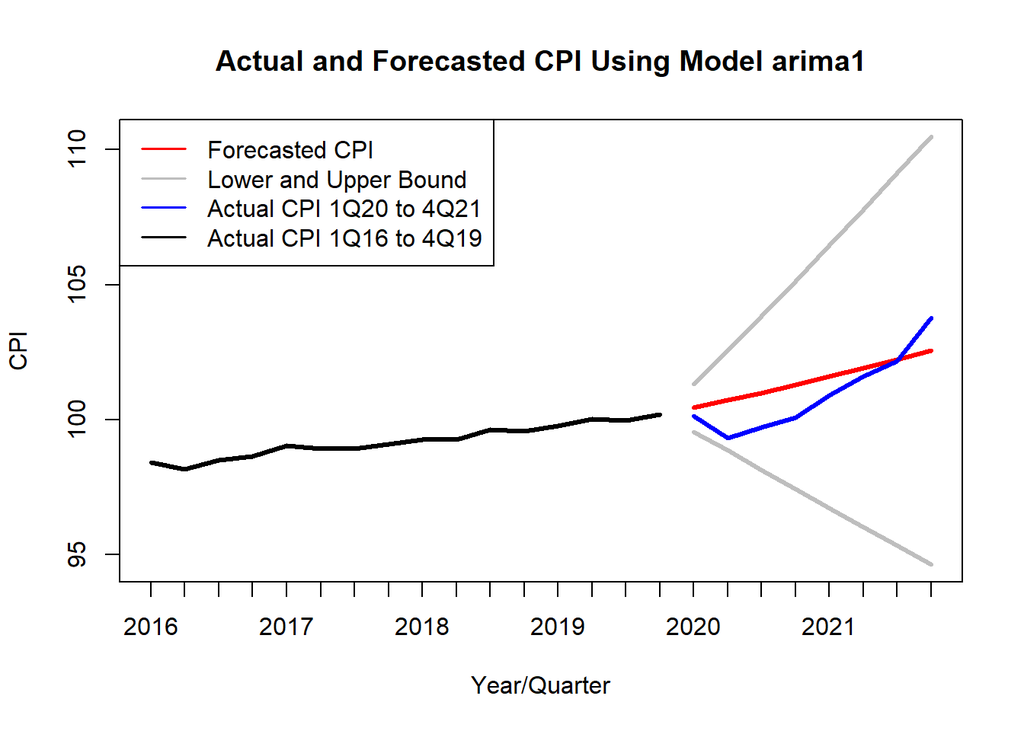

For model `arima2`, I suppressed the code to reduce the length of the document since it is similar to what I did for model `arima1`.

```
##
## Forecasted dCPI 2020Q1 to 2021Q4 Using arima2 Model
## =================================
##       Point Forecast Lo 95  Hi 95
## ---------------------------------
## 42 Q4     0.301      -0.576 1.177
## 43 Q1     0.296      -0.666 1.257
## 43 Q2     0.333      -0.668 1.335
## 43 Q3     0.316      -0.689 1.321
## 43 Q4     0.342      -0.669 1.353
## 44 Q1     0.323      -0.688 1.334
## 44 Q2     0.343      -0.669 1.356
## 44 Q3     0.326      -0.687 1.338
## ---------------------------------
```

```
##
## Accuracy Measures of arima2 Model for 8-Steps Ahead Forecasting
## =============================================================
##                ME   RMSE   MAE    MPE     MAPE   MASE   ACF1
## -------------------------------------------------------------
## Training set 0.0005 0.442 0.301 -538.203 780.460 0.662 -0.012
## Test set     0.124  0.651 0.493 115.255  115.255 1.083
## -------------------------------------------------------------
```

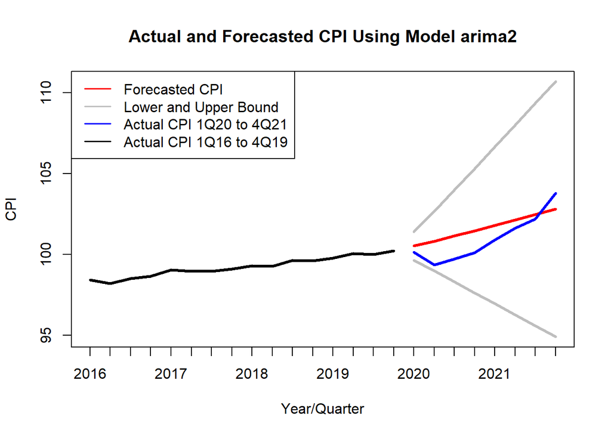

There seemed to be negligible differences between the models `arima1` and `arima2`, so it might be better to go with the simpler `arima2` when using ARIMA models for forecasting Singapore CPI.

### 11.2 Forecast Performance of ARDL and ARDL-EC Models

To forecast the ARDL and ARDL-EC models, we need values for the exogenous variables. However, as there are lags in the model as well, **`forecast`** and **`predict`** functions do not work well with the underlying **`dynlm`** objects of these models. To resolve this, we have to use the **`dLagM`** package function **`ardlDlm`** to fit the ARDL model. The **`dLagM`** package also contains its own **`forecast`** function.

```r
ardl.new <- ardlDlm(formula = dCPI ~ dDSPI + dCLI, # Indicate variables for the ARDL model
                    data = data.frame(diff.train),
                    p = 2, q = 4, # Include 2 lags for exogenous variables, 4 lags for dependent variable
                    remove = list(p = list(dDSPI = c(2)))) # Remove second lag for dDSPI so that model is same as auto_ardl

stargazer(ardl.new$model, type = "text",
          title = "ARDL Regression Using dLagM Package",
          dep.var.labels.include = F,
          column.labels = "CPI.t")
```

```
##
## ARDL Regression Using dLagM Package
## ===============================================
##                         Dependent variable:
##                     ---------------------------
##                                CPI.t
## -----------------------------------------------
## dDSPI.t                      0.039***
##                               (0.009)
##
## dDSPI.1                      0.028***
##                               (0.010)
##
## dCLI.t                        -0.040*
##                               (0.022)
##
## dCLI.1                        0.057**
##                               (0.023)
##
## dCLI.2                         0.032
##                               (0.021)
##
## dCPI.1                       0.257***
##                               (0.077)
##
## dCPI.2                        0.192**
##                               (0.075)
##
## dCPI.3                         0.013
##                               (0.075)
##
## dCPI.4                        0.176**
##                               (0.070)
##
## Constant                      0.097**
##                               (0.047)
##
## -----------------------------------------------
## Observations                    163
## R2                             0.467
## Adjusted R2                    0.436
## Residual Std. Error      0.389 (df = 153)
## F Statistic           14.895*** (df = 9; 153)
## ===============================================
## Note:               *p<0.1; **p<0.05; ***p<0.01
```

```r
x.new <- rbind(as.vector(diff.test["2020/2021", 2]), as.vector(diff.test["2020/2021", 3])) # function only accepts new data in matrix class

ardl_h8 <- dLagM::forecast(model = ardl.new, x = x.new, h = 8, interval = T, level = 0.95)

stargazer(ardl_h8$forecasts,
          type = "text",
          title = "Forecasted dCPI 2020Q1 to 2021Q4 Using ardl Model",
          summary = F)
```

```
##
## Forecasted dCPI 2020Q1 to 2021Q4 Using ardl Model
## ========================
##   95% LB Forecast 95% UB
## ------------------------
## 1 -0.656  0.103   0.851
## 2 -1.119  -0.336  0.465
## 3 -1.392  -0.512  0.256
## 4 -0.529  0.226   0.990
## 5 -0.125  0.756   1.607
## 6 -0.165  0.706   1.484
## 7 -0.097  0.735   1.549
## 8 -0.096  0.796   1.631
## ------------------------
```

```r
# To use the accuracy function in the forecast package, we need to trick it into thinking it is a object of class "forecast"

ardl_h8adj <- structure(list(level = 95,
                             mean = ardl_h8$forecasts$Forecast,
                             lower = ardl_h8$forecasts$`95% LB`,
                             upper = ardl_h8$forecasts$`95% UB`,
                             x = diff.train[, 1],
                             fitted = c(rep(NA, 4), ardl.new$model$fitted.values),
                             residuals = c(rep(NA, 4), ardl.new$model$residuals)),
                        class = "forecast")

stargazer(accuracy(object = ardl_h8adj, x = diff.test["2020/2021"]$dCPI),
          type = "text",
          title = "Accuracy Measures of ardl Model for 8-Steps Ahead Forecasting")
```

```
##
## Accuracy Measures of ardl Model for 8-Steps Ahead Forecasting
## =====================================================
##               ME   RMSE   MAE    MPE     MAPE   MASE
## -----------------------------------------------------
## Training set  -0   0.377 0.269 -560.441 772.280 0.713
## Test set     0.137 0.466 0.338  76.297  83.043  0.896
## -----------------------------------------------------
```

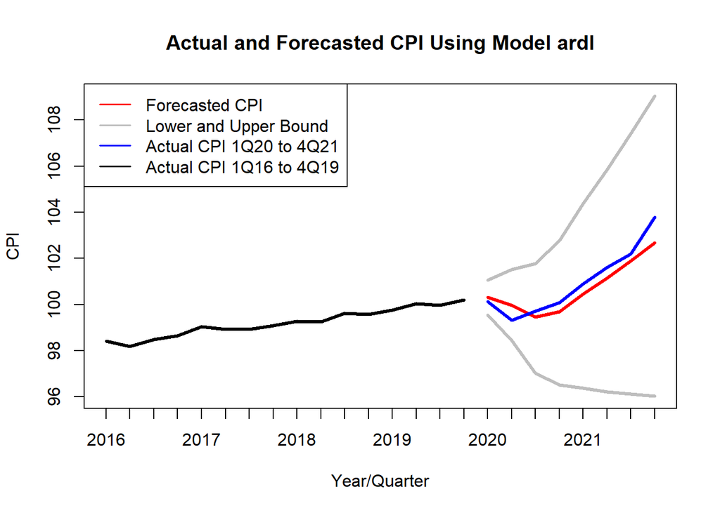

For the ARDL-ECM, since we have found cointegration we could simply obtain the forecast in levels since there is a long-run model `ardl_lr`. Of course, there will still be a need to model and forecast it using the **`dLagM`** package for it to work.

```r
ardlecm.new <- dLagM::ardlDlm(formula = CPI ~ DSPI + CLI, data = data.frame(train), p = 2, q = 3)

stargazer(ardlecm.new$model,
          type = "text",
          title = "ECM Regression Using dLagM Package",
          dep.var.labels.include = F,
          column.labels = "CPI.t")
```

```
##
## ECM Regression Using dLagM Package
## ===============================================
##                         Dependent variable:
##                     ---------------------------
##                                CPI.t
## -----------------------------------------------
## DSPI.t                       0.037***
##                               (0.009)
##
## DSPI.1                        -0.006
##                               (0.015)
##
## DSPI.2                        -0.019*
##                               (0.010)
##
## CLI.t                         -0.031
##                               (0.021)
##
## CLI.1                        0.090***
##                               (0.033)
##
## CLI.2                         -0.040*
##                               (0.021)
##
## CPI.1                        1.166***
##                               (0.077)
##
## CPI.2                         -0.070
##                               (0.117)
##
## CPI.3                         -0.126*
##                               (0.072)
##
## Constant                      -0.120
##                               (0.443)
##
## -----------------------------------------------
## Observations                    165
## R2                             0.999
## Adjusted R2                    0.999
## Residual Std. Error      0.379 (df = 155)
## F Statistic         30,570.540*** (df = 9; 155)
## ===============================================
## Note:               *p<0.1; **p<0.05; ***p<0.01
```

```r
newdata <- rbind(as.vector(test["2020/2021", 2]), as.vector(test["2020/2021", 3]))

ecm_h8 <- dLagM::forecast(model = ardlecm.new, x = newdata, h = 8, interval = T, level = 0.95)

stargazer(ecm_h8$forecasts,
          type = "text",
          title = "Forecasted dCPI 2020Q1 to 2021Q4 Using ecm Model",
          summary = F)
```

```
##
## Forecasted dCPI 2020Q1 to 2021Q4 Using ecm Model
## =========================
##   95% LB Forecast 95% UB
## -------------------------
## 1 99.530 100.229  100.957
## 2 98.806  99.803  100.999
## 3 97.859  99.287  100.862
## 4 97.651  99.398  101.262
## 5 97.777  99.864  101.973
## 6 98.186 100.415  102.689
## 7 98.818 101.158  103.565
## 8 99.393 101.898  104.457
## -------------------------
```

```r
# Since forecast values are CPI at level, we cannot directly compare to the accuracy measures of other models since they have different scales
# We can get the first difference CPI by taking the difference of the forecasted values

dcpi_ecm <- data.frame(fcst = na.omit(diff(append(ecm_h8$forecasts$Forecast, as.vector(last(train$CPI)), 0))),
                       lowerb = na.omit(diff(append(ecm_h8$forecasts$`95% LB`, as.vector(last(train$CPI)), 0))),
                       upperb = na.omit(diff(append(ecm_h8$forecasts$`95% UB`, as.vector(last(train$CPI)), 0))))

# Creating structure of class "forecast" that can be used with the accuracy function

ecm_h8adj <- structure(list(level = 95,
                            mean = dcpi_ecm$fcst,
                            lower = dcpi_ecm$lowerb,
                            upper = dcpi_ecm$upperb,
                            x = diff.train[, 1],
                            fitted = c(rep(NA, 2), r_ecm$fitted.values),
                            residuals = c(rep(NA, 2), r_ecm$residuals)),
                       class = "forecast")

stargazer(accuracy(object = ecm_h8adj, x = diff.test["2020/2021"]$dCPI),
          type = "text",
          title = "Accuracy Measures of ecm Model for 8-Steps Ahead Forecasting")
```

```
##
## Accuracy Measures of ecm Model for 8-Steps Ahead Forecasting
## =====================================================
##               ME   RMSE   MAE    MPE     MAPE   MASE
## -----------------------------------------------------
## Training set  -0   0.368 0.269 -317.329 567.977 0.713
## Test set     0.236 0.491 0.394  71.472  78.533  1.046
## -----------------------------------------------------
```

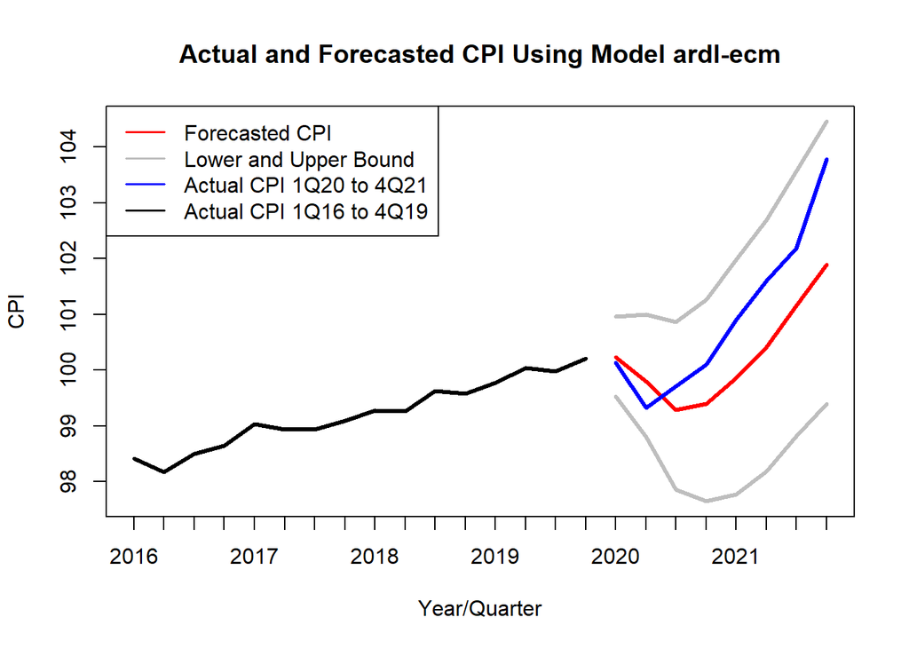

### 11.3 Forecast Performance of VAR and VEC Models

Forecasting VAR and VEC models is much simpler that for ARDL and ARDL-EC models in R. It simply requires the **`predict`** function in base R. However, we still need to create a list object of class `forecast` that works with the **`accuracy`** function.

```r
var_h8 <- predict(object = var, n.ahead = 8, ci = 0.95)

stargazer(var_h8$fcst,
          type = "text",
          title = c("Forecasted dCPI from 1Q20 to 4Q21", "Forecasted dDSPI from 1Q20 to 4Q21", "Forecasted dCLI from 1Q20 to 4Q21"))
```

```
##
## Forecasted dCPI from 1Q20 to 4Q21
## ========================
## fcst  lower  upper  CI
## ------------------------
## 0.090 -0.721 0.900 0.811
## 0.164 -0.763 1.091 0.927
## 0.207 -0.795 1.210 1.002
## 0.261 -0.760 1.283 1.022
## 0.294 -0.735 1.324 1.029
## 0.315 -0.716 1.346 1.031
## 0.323 -0.709 1.354 1.031
## 0.326 -0.706 1.357 1.032
## ------------------------
##
## Forecasted dDSPI from 1Q20 to 4Q21
## =========================
## fcst   lower  upper  CI
## -------------------------
## -0.360 -7.394 6.675 7.034
## -0.242 -7.630 7.147 7.388
## -0.118 -7.599 7.362 7.481
## 0.073  -7.474 7.621 7.547
## 0.128  -7.423 7.679 7.551
## 0.088  -7.465 7.641 7.553
## 0.047  -7.506 7.601 7.554
## 0.031  -7.523 7.584 7.554
## -------------------------
##
## Forecasted dCLI from 1Q20 to 4Q21
## ========================
## fcst  lower  upper  CI
## ------------------------
## 0.132 -2.921 3.185 3.053
## 0.623 -2.588 3.833 3.210
## 0.689 -2.645 4.024 3.334
## 0.637 -2.757 4.032 3.395
## 0.578 -2.829 3.985 3.407
## 0.520 -2.892 3.932 3.412
## 0.487 -2.927 3.901 3.414
## 0.476 -2.939 3.890 3.414
## ------------------------
```

```r
# Creating structure of class "forecast" that can be used with the accuracy function

var_acc_list <- list()

for (i in 1:3) {
  fc <- structure(list(level = 95,
                       mean = var_h8$fcst[[i]][,"fcst"],
                       lower = var_h8$fcst[[i]][,"lower"],
                       upper = var_h8$fcst[[i]][,"upper"],
                       x = diff.train[,i],
                       fitted = c(NA, NA, fitted(var)[,i]),
                       residuals = c(NA, NA, resid(var)[,i])),
                  class = "forecast")

  name <- paste(names(var_h8$fcst[i]), "_acc", sep = "")

  var_acc_list[[name]] <- fc
}

stargazer(accuracy(object = var_acc_list$dCPI_acc, x = diff.test["2020/2021"]$dCPI),
          type = "text",
          title = "Accuracy Measures of var Model for 8-Steps Ahead Forecasting for dCPI")
```

```
##
## Accuracy Measures of var Model for 8-Steps Ahead Forecasting for dCPI
## =====================================================
##               ME   RMSE   MAE    MPE     MAPE   MASE
## -----------------------------------------------------
## Training set  -0   0.405 0.283 -647.127 853.314 0.751
## Test set     0.199 0.623 0.482  83.371  83.371  1.279
## -----------------------------------------------------
```

```r
stargazer(accuracy(object = var_acc_list$dDSPI_acc, x = diff.test["2020/2021"]$dDSPI),
          type = "text",
          title = "Accuracy Measures of var Model for 8-Steps Ahead Forecasting for dDSPI")
```

```
##
## Accuracy Measures of var Model for 8-Steps Ahead Forecasting for dDSPI
## ====================================================
##               ME   RMSE   MAE    MPE    MAPE   MASE
## ----------------------------------------------------
## Training set  -0   3.512 2.331 25.063  242.126 0.913
## Test set     1.694 5.103 4.527 100.261 100.261 1.774
## ----------------------------------------------------
```

```r
stargazer(accuracy(object = var_acc_list$dCLI_acc, x = diff.test["2020/2021"]$dCLI),
          type = "text",
          title = "Accuracy Measures of var Model for 8-Steps Ahead Forecasting for dCLI")
```

```
##
## Accuracy Measures of var Model for 8-Steps Ahead Forecasting for dCLI
## ====================================================
##               ME   RMSE   MAE    MPE    MAPE   MASE
## ----------------------------------------------------
## Training set  -0   1.524 1.144           Inf   0.950
## Test set     0.532 2.709 2.012 224.208 224.208 1.672
## ----------------------------------------------------
```

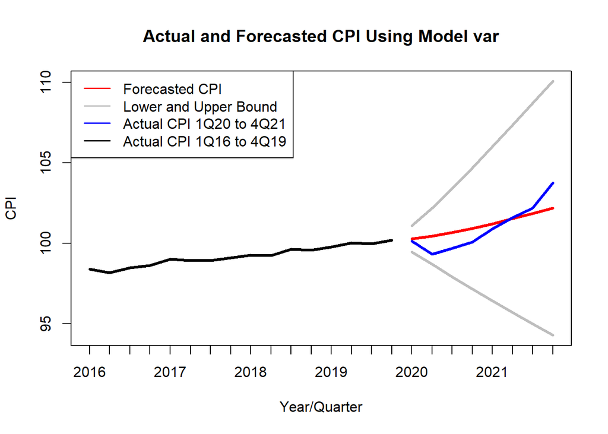

For the VECM, R does not have a function that allows us to forecast the VECM in differences. We have to use the VAR in levels that was converted from the model `vec_ecm` using the **`vec2var`** function.

```r
vecm_h8 <- predict(var_ecm, n.ahead = 8, ci = 0.95)

stargazer(vecm_h8$fcst,
          type = "text",
          title = c("Forecasted dCPI from 1Q20 to 4Q21", "Forecasted dDSPI from 1Q20 to 4Q21", "Forecasted dCLI from 1Q20 to 4Q21"))
```

```
##
## Forecasted dCPI from 1Q20 to 4Q21
## ============================
## fcst    lower   upper   CI
## ----------------------------
## 100.204 99.450 100.958 0.754
## 100.202 98.950 101.454 1.252
## 100.205 98.459 101.950 1.746
## 100.243 98.064 102.421 2.178
## 100.315 97.745 102.885 2.570
## 100.419 97.485 103.353 2.934
## 100.550 97.273 103.828 3.277
## 100.705 97.100 104.310 3.605
## ----------------------------
##
## Forecasted dDSPI from 1Q20 to 4Q21
## ============================
## fcst   lower   upper    CI
## ----------------------------
## 94.655 88.126 101.184 6.529
## 93.509 83.187 103.832 10.323
## 92.629 80.457 104.801 12.172
## 92.065 78.615 105.516 13.450
## 91.728 77.111 106.345 14.617
## 91.537 75.881 107.193 15.656
## 91.461 74.921 108.001 16.540
## 91.482 74.178 108.786 17.304
## ----------------------------
##
## Forecasted dCLI from 1Q20 to 4Q21
## =============================
## fcst     lower   upper   CI
## -----------------------------
## 104.640 101.655 107.624 2.984
## 105.331 100.406 110.256 4.925
## 106.224 99.930  112.517 6.293
## 107.134 99.791  114.477 7.343
## 108.003 99.856  116.150 8.147
## 108.808 100.041 117.575 8.767
## 109.556 100.291 118.820 9.264
## 110.258 100.577 119.938 9.680
## -----------------------------
```

```r
# Just as in the ARDL-ECM case, the forecasted values are in levels and we cannot directly compare to the other models.
# Need to take the difference of the forecasted values

dforecast_vecm <- list()

for (i in 1:3) {
  dforecast <- data.frame(fcst = na.omit(diff(append(vecm_h8$fcst[[i]][,"fcst"], as.vector(last(train$CPI)), 0))),
                          lowerb = na.omit(diff(append(vecm_h8$fcst[[i]][,"lower"], as.vector(last(train$CPI)), 0))),
                          upperb = na.omit(diff(append(vecm_h8$fcst[[i]][,"upper"], as.vector(last(train$CPI)), 0))))

  name <- paste("diff_", names(vecm_h8$fcst[i]), sep = "")

  dforecast_vecm[[name]] <- dforecast
}

# Create "forecast" structure to be used with the accuracy function

vecm_acc_list <- list()

for (i in 1:3) {
  fc <- structure(list(level = 95,
                       mean = dforecast_vecm[[i]][,"fcst"],
                       lower = dforecast_vecm[[i]][,"lowerb"],
                       upper = dforecast_vecm[[i]][,"upperb"],
                       x = diff.train[,i],
                       fitted = c(rep(NA, 2), fitted(vec_ecm[["rlm"]])[,i]),
                       residuals = c(rep(NA, 2), resid(vec_ecm[["rlm"]])[,i])),
                  class = "forecast")

  name <- paste(names(dforecast_vecm[i]), "_acc", sep = "")

  vecm_acc_list[[name]] <- fc
}

stargazer(accuracy(object = vecm_acc_list$diff_CPI_acc, x = diff.test["2020/2021"]$dCPI),
          type = "text",
          title = "Accuracy Measures of vecm Model for 8-Steps Ahead Forecasting for dCPI")
```

```
##
## Accuracy Measures of vecm Model for 8-Steps Ahead Forecasting for dCPI
## =====================================================
##               ME   RMSE   MAE    MPE     MAPE   MASE
## -----------------------------------------------------
## Training set   0   0.405 0.283 -648.788 853.811 0.751
## Test set     0.385 0.715 0.603  90.651  90.651  1.598
## -----------------------------------------------------
```

```r
stargazer(accuracy(object = vecm_acc_list$diff_DSPI_acc, x = diff.test["2020/2021"]$dDSPI),
          type = "text",
          title = "Accuracy Measures of vecm Model for 8-Steps Ahead Forecasting for dDSPI")
```

```
##
## Accuracy Measures of vecm Model for 8-Steps Ahead Forecasting for dDSPI
## ===================================================
##               ME   RMSE   MAE   MPE    MAPE   MASE
## ---------------------------------------------------
## Training set  -0   3.340 2.253 17.571 231.927 0.882
## Test set     2.741 5.165 4.670 56.722 98.690  1.829
## ---------------------------------------------------
```

```r
stargazer(accuracy(object = vecm_acc_list$diff_CLI_acc, x = diff.test["2020/2021"]$dCLI),
          type = "text",
          title = "Accuracy Measures of vecm Model for 8-Steps Ahead Forecasting for dCLI")
```

```
##
## Accuracy Measures of vecm Model for 8-Steps Ahead Forecasting for dCLI
## =====================================================
##                ME   RMSE   MAE    MPE    MAPE   MASE
## -----------------------------------------------------
## Training set   -0   1.524 1.144           Inf   0.951
## Test set     -0.206 3.489 2.503 307.039 307.039 2.080
## -----------------------------------------------------
```

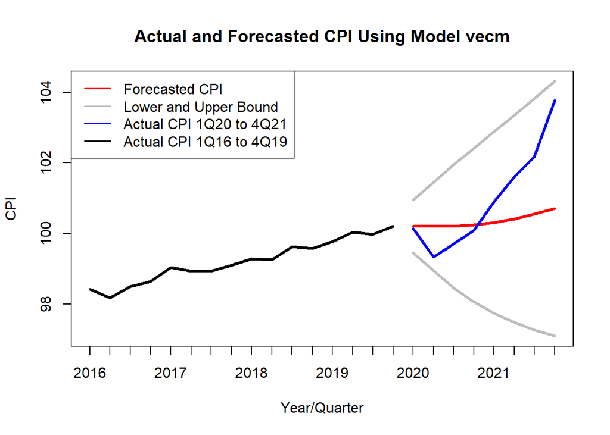

## 12 Conclusion

In this project, I have detailed the 5 common time series models used in forecasting that I have learnt. Through this project, we can experience how using R for time series analysis feels like. It is not as simple as using EViews or Stata as the packages have their own quirks and functions can be repeated across packages but only serve models that are built by those packages.

The ARIMA models gives us a quick and easy forecasting method as we are just using the lags of CPI and its residuals, without the need of exogenous variables. However, whether in-sample or out-of-sample prediction, these models do not capture much of the magnitude of the movements in CPI although they are able to capture its patterns.

The ARDL model was able to use exogenous variables to provide a better fit to the data, both in-sample and out-of-sample. However, for out-of-sample prediction, I had used actual data of the exogenous variables, which cannot happen for real-world forecasting methods. The correct method would be to use another model to forecast the exogenous variables and use these forecasted values fit the out-of-sample prediction. This means that the accuracy of the forecast depends on both the CPI model and the models of other variables.

The VAR model can be used when all variables are endogenous and can be used to explain one another. By using VAR models, we solved the problem of ARDL models by allowing variables to be forecasted at the same time. However, despite the good in-sample fit, the out-of-sample fit is disappointing. This is likely due to the findings of the Granger Causality Test, where DSPI and CLI can be used to improve the prediction of CPI but other variables have lack of granger causality. This would be a model misspecification and would lead to poor forecasting results.

The Johansen Test was used to determine if cointegration exists between the variables and we found that there is a cointegrating relationship. This was the reason for using the ECM and VECM. The ECM had much better out-of-sample forecasts than the VECM, although this could be attributed to using actual data for the exogenous variables. However, we can see that the VECM was unable to capture the rising trend of the CPI in levels through the forecast, which again could be due to model misspecification as in the VAR model case.

For the case of forecasting Singapore CPI, ARIMA models seem to have the best forecasting ability among the models given its simplicity. It would be interesting to find out if using ARDL with forecasted exogenous variables could still provide a better forecast accuracy than the ARIMA models in the future. As for the VAR and VECM models, there would be a need to re-specify the models or simply fit the models individually just as in the ARDL case. I had also ignored the effects of seasonality in this project, which I would discuss separately in the future as well.